# Machine Learning / Aprendizagem Automática

## Sara C. Madeira, 2018/19

# ML Project - Learning from Mental Health in Tech Surveys

## Team

**Janik Agnieszka (52315), Makselon Jakub (52341), Müller Marcel (52357), Sprychała Maciej (52356)**.

## Dataset

The dataset to be analysed is **`mental-heath-in-tech-2016.csv`**, made avaliable together with this project description.

This dataset, downloaded from [Kaggle](https://www.kaggle.com), contains data from [OSMI Mental Health in Tech Survey](https://www.kaggle.com/osmi/mental-health-in-tech-survey), collected during a survey aiming at measuring **attitudes towards mental health and frequency of mental health disorders in the Tech workplace**, carried out in 2016.

The **1433 surveys/instances** are described by **63 categorical/numerical features**, where the following questions were asked:

- Q1 - "Are you self-employed?"
- Q2 - "How many employees does your company or organization have?"
- Q3 - "Is your employer primarily a tech company/organization?"
- Q4 - "Is your primary role within your company related to tech/IT?"
- Q5 - "Does your employer provide mental health benefits as part of healthcare coverage?"
- Q6 - "Do you know the options for mental health care available under your employer-provided coverage?"
- Q7 - "Has your employer ever formally discussed mental health (for example, as part of a wellness campaign or other official communication)?"
- Q8 - "Does your employer offer resources to learn more about mental health concerns and options for seeking help?"
- Q9 - "Is your anonymity protected if you choose to take advantage of mental health or substance abuse treatment resources provided by your employer?"
- Q10 - "If a mental health issue prompted you to request a medical leave from work, asking for that leave would be:..."
- Q11 - "Do you think that discussing a mental health disorder with your employer would have negative consequences?"
- Q12 - "Do you think that discussing a physical health issue with your employer would have negative consequences?"
- Q13 - "Would you feel comfortable discussing a mental health disorder with your coworkers?"
- Q14 - "Would you feel comfortable discussing a mental health disorder with your direct supervisor(s)?"
- Q15 - "Do you feel that your employer takes mental health as seriously as physical health?"
- Q16 - "Have you heard of or observed negative consequences for co-workers who have been open about mental health issues in your workplace?"
- Q17 - "Do you have medical coverage (private insurance or state-provided) which includes treatment of mental health issues?"
- Q18 - "Do you know local or online resources to seek help for a mental health disorder?"
- Q19 - "If you have been diagnosed or treated for a mental health disorder, do you ever reveal this to clients or business contacts?"
- Q20 - "If you have revealed a mental health issue to a client or business contact, do you believe this has impacted you negatively?"
- Q21 - "If you have been diagnosed or treated for a mental health disorder, do you ever reveal this to coworkers or employees?"
- Q22 - "If you have revealed a mental health issue to a coworker or employee, do you believe this has impacted you negatively?"
- Q23 - "Do you believe your productivity is ever affected by a mental health issue?"
  - Q24 - "If yes, what percentage of your work time (time performing primary or secondary job functions) is affected by a mental health issue?"
- Q25 - "Do you have previous employers?"
- Q26 - "Have your previous employers provided mental health benefits?"
- Q27 - "Were you aware of the options for mental health care provided by your previous employers?"
- Q28 - "Did your previous employers ever formally discuss mental health (as part of a wellness campaign or other offi8cial communication)?"
- Q29 - "Did your previous employers provide resources to learn more about mental health issues and how to seek help?"
- Q30 - "Was your anonymity protected if you chose to take advantage of mental health or substance abuse treatment resources with previous employers?"
- Q31 - "Do you think that discussing a mental health disorder with previous employers would have negative consequences?"
- Q32 - "Do you think that discussing a physical health issue with previous employers would have negative consequences?"
- Q33 - "Would you have been willing to discuss a mental health issue with your previous co-workers?"
- Q34 - "Would you have been willing to discuss a mental health issue with your direct supervisor(s)?"
- Q35 - "Did you feel that your previous employers took mental health as seriously as physical health?"
- Q36 - "Did you hear of or observe negative consequences for co-workers with mental health issues in your previous workplaces?"
- Q37 - "Would you be willing to bring up a physical health issue with a potential employer in an interview?"
  - Q38 - "Why or why not?"
- Q39 - "Would you bring up a mental health issue with a potential employer in an interview?"
  - Q40 - "Why or why not?"
- Q41 - "Do you feel that being identified as a person with a mental health issue would hurt your career?"
- Q42 - "Do you think that team members/co-workers would view you more negatively if they knew you suffered from a mental health issue?"
- Q43 - "How willing would you be to share with friends and family that you have a mental illness?"
- Q44 - "Have you observed or experienced an unsupportive or badly handled response to a mental health issue in your current or previous workplace?"
- Q45 - "Have your observations of how another individual who discussed a mental health disorder made you less likely to reveal a mental health issue yourself in your current workplace?"
- Q46 - "Do you have a family history of mental illness?"
- Q47 - "Have you had a mental health disorder in the past?"
- **Q48 - "Do you currently have a mental health disorder?"**
  - **Q49 - "If yes, what condition(s) have you been diagnosed with?"**
  - **Q50 - "If maybe, what condition(s) do you believe you have?"**
- Q51 - "Have you been diagnosed with a mental health condition by a medical professional?"
  - Q52 - "If so, what condition(s) were you diagnosed with?"
- Q53 - "Have you ever sought treatment for a mental health issue from a mental health professional?"
- Q54 - "If you have a mental health issue, do you feel that it interferes with your work when being treated effectively?"
- Q55 - "If you have a mental health issue, do you feel that it interferes with your work when NOT being treated effectively?"
- Q56 - "What is your age?"
- Q57 - "What is your gender?"
- Q58 - "What country do you live in?"
  - Q59 - "What US state or territory do you live in?"
- Q60 - "What country do you work in?"
  - Q61 - "What US state or territory do you work in?"
- Q62 - "Which of the following best describes your work position?"
- Q63 - "Do you work remotely?"

**IMPORTANT NOTES:**

1. **Some questions might not be asked**. For example, Q49 and Q50 will only be asked if Q48 is "yes".
2. Data can contain **errors/typos**, whose correction might improve the analysis.
3. Data can contain **missing values**, that you might decide to fill.
4. **Not all features are necessarily important** for the analysis.
5. Depending on the analysis, **some features might have to be excluded**. An example is when we want to predict a certain feature and there are other features that only have values for certain values of the target.

## Task 0 (Know your Data) - Preliminary Data Analysis

```python
import pandas as pd
import numpy as np

import matplotlib
import matplotlib.pyplot as plt

pd.set_option('display.max_rows', 500)
pd.set_option('display.max_columns', 500)
pd.set_option('display.width', 1000)
```

## 0.1. Loading Data

```python
df = pd.read_csv('mental-heath-in-tech-2016.csv')
df.head()
```

|  | Are you self-employed? | How many employees does your company or organization have? | Is your employer primarily a tech company/organization? | Is your primary role within your company related to tech/IT? | Does your employer provide mental health benefits as part of healthcare coverage? | Do you know the options for mental health care available under your employer-provided coverage? | Has your employer ever formally discussed mental health (for example, as part of a wellness campaign or other official communication)? | Does your employer offer resources to learn more about mental health concerns and options for seeking help? | Is your anonymity protected if you choose to take advantage of mental health or substance abuse treatment resources provided by your employer? | If a mental health issue prompted you to request a medical leave from work, asking for that leave would be: | Do you think that discussing a mental health disorder with your employer would have negative consequences? | Do you think that discussing a physical health issue with your employer would have negative consequences? | Would you feel comfortable discussing a mental health disorder with your coworkers? | Would you feel comfortable discussing a mental health disorder with your direct supervisor(s)? | Do you feel that your employer takes mental health as seriously as physical health? | Have you heard of or observed negative consequences for co-workers who have been open about mental health issues in your workplace? | Do you have medical coverage (private insurance or state-provided) which includes treatment of mental health issues? | Do you know local or online resources to seek help for a mental health disorder? | If you have been diagnosed or treated for a mental health disorder, do you ever reveal this to clients or business contacts? | If you have revealed a mental health issue to a client or business contact, do you believe this has impacted you negatively? | If you have been diagnosed or treated for a mental health disorder, do you ever reveal this to coworkers or employees? | If you have revealed a mental health issue to a coworker or employee, do you believe this has impacted you negatively? | Do you believe your productivity is ever affected by a mental health issue? | If yes, what percentage of your work time (time performing primary or secondary job functions) is affected by a mental health issue? | Do you have previous employers? | Have your previous employers provided mental health benefits? | Were you aware of the options for mental health care provided by your previous employers? | Did your previous employers ever formally discuss mental health (as part of a wellness campaign or other official communication)? | Did your previous employers provide resources to learn more about mental health issues and how to seek help? | … |
| --- | --- | --- | --- | --- | --- | --- | --- | --- | --- | --- | --- | --- | --- | --- | --- | --- | --- | --- | --- | --- | --- | --- | --- | --- | --- | --- | --- | --- | --- | --- |
| 0 | 0 | 26-100 | 1.0 | NaN | Not eligible for coverage / N/A | NaN | No | No | I don't know | Very easy | No | No | Maybe | Yes | I don't know | No | NaN | NaN | NaN | NaN | NaN | NaN | NaN | NaN | 1 | No, none did | N/A (not currently aware) | I don't know | None did | … |
| 1 | 0 | 6-25 | 1.0 | NaN | No | Yes | Yes | Yes | Yes | Somewhat easy | No | No | Maybe | Yes | Yes | No | NaN | NaN | NaN | NaN | NaN | NaN | NaN | NaN | 1 | Yes, they all did | I was aware of some | None did | Some did | … |
| 2 | 0 | 6-25 | 1.0 | NaN | No | NaN | No | No | I don't know | Neither easy nor difficult | Maybe | No | Maybe | Maybe | I don't know | No | NaN | NaN | NaN | NaN | NaN | NaN | NaN | NaN | 1 | No, none did | N/A (not currently aware) | None did | Some did | … |
| 3 | 1 | NaN | NaN | NaN | NaN | NaN | NaN | NaN | NaN | NaN | NaN | NaN | NaN | NaN | NaN | NaN | 1.0 | Yes, I know several | Sometimes, if it comes up | I'm not sure | Sometimes, if it comes up | I'm not sure | Yes | 1-25% | 1 | Some did | N/A (not currently aware) | None did | None did | … |
| 4 | 0 | 6-25 | 0.0 | 1.0 | Yes | Yes | No | No | No | Neither easy nor difficult | Yes | Maybe | Maybe | No | No | No | NaN | NaN | NaN | NaN | NaN | NaN | NaN | NaN | 1 | I don't know | N/A (not currently aware) | Some did | None did | … |

## 0.2. Understanding Data

In this task you should understand better the features you have, the distribution of values, potential errors, etc and plan/describe what data preprocessing steps should be performed next.

### Data Exploration

As a first step we explore what questions we have and what dependencies they my be involved in:

- Q1 is asking for self employment and influences what questions are getting asked by what people
- If the instance is self employed it did not answer questions 2 to 16, but answer question 17 to 24.
- Equivalently instances who are not self employed are answering 2 to 16, but not 17 to 24.
- Questions 26-36 were only answered by instances with previous employers.
- Similar to Q1, also Q48 asking if the instance is suffering from a mental issue, is also determining if the next questions asking for more details about the desease (Q49 to Q55) are applicable.

We have to take this dependencies into account for our further classification steps later on.

## Dealing with Missing values

Another approach is to put the answer on the left most place of any lineraliy orderd scale.

```python
path_to_df = 'mental-heath-in-tech-2016.csv'
refactored_df = pd.read_csv(path_to_df)
names = ['Q{}'.format(i+1) for i in range(len(df.columns))]
refactored_df.columns = names

#Questions 2-16 were not answered by self-emplyed people
for i in range(2,17):
    refactored_df["Q"+str(i)] = refactored_df.apply(lambda row: "Not asked" if row["Q1"] == 1 else row["Q"+str(i)],axis=1)

#Questions 2-16 were not answered by non self-emplyed people
for i in range(17,25):
    refactored_df["Q"+str(i)] = refactored_df.apply(lambda row: "Not asked" if row["Q1"] == 0 else row["Q"+str(i)],axis=1)

#Questions 26-36 were not answered if no previous employers
for i in range(26,37):
    refactored_df["Q"+str(i)] = refactored_df.apply(lambda row: "Not asked" if row["Q25"] == 0 else row["Q"+str(i)],axis=1)

refactored_df["Q6"] = refactored_df["Q6"].map(lambda x: "No" if x is np.nan  else x)

refactored_df["Q24"] = refactored_df.apply(lambda row: "Not applicable to me" if row["Q23"] not in ["Yes","Not asked"] else row["Q24"],axis=1)

refactored_df["Q44"] = refactored_df["Q44"].map(lambda x: "Maybe/Not sure" if x is np.nan else x)
refactored_df["Q45"] = refactored_df["Q45"].map(lambda x: "Not answered" if x is np.nan else x)# may be possible to make some assumptions

#merge Qs 49+50+52 into Q49
refactored_df["Q49"] = refactored_df.apply(lambda row: row["Q49"] if row["Q48"] == "Yes" else row["Q50"], axis=1)
refactored_df["Q49"] = refactored_df.apply(lambda row: "Not identified" if row["Q48"] == "No" else row["Q49"], axis=1)
refactored_df["Q49"] = refactored_df.apply(lambda row: row["Q52"] if row["Q51"] == "Yes" and row["Q49"] is np.nan else row["Q49"], axis=1)
refactored_df["Q49"] = refactored_df.apply(lambda row: "Not identified" if row["Q49"] is np.nan else row["Q49"], axis=1)
refactored_df["Q49"] = refactored_df["Q49"].map(lambda x: "Not identified" if x in ["We're all hurt, right?!"] else x)
refactored_df.drop(["Q50","Q52"], axis=1, inplace=True)

age_mean = round(refactored_df["Q56"].map(lambda x: x if x > 15 and x < 90 else np.nan).mean())
refactored_df["Q56"] = refactored_df["Q56"].map(lambda x: x if x > 15 and x < 90 else age_mean)

refactored_df["Q57"] = refactored_df["Q57"].map(lambda x: "F" if isinstance(x,str) and x.lower().strip() in ["woman","female","f","fm","fem","f|"] else x)
refactored_df["Q57"] = refactored_df["Q57"].map(lambda x: "M" if isinstance(x,str) and x.lower().strip() in ["male","m","man","dude","m|"] else x)
refactored_df["Q57"] = refactored_df["Q57"].map(lambda x: "M" if isinstance(x,str) and x.lower().strip().find("ma") == 0 else x)
refactored_df["Q57"] = refactored_df["Q57"].map(lambda x: "F" if isinstance(x,str) and x.lower().strip().find("female") >= 0 else x)
refactored_df["Q57"] = refactored_df["Q57"].map(lambda x: "F" if isinstance(x,str) and x.lower().strip().find("woman") >= 0 else x)
refactored_df["Q57"] = refactored_df["Q57"].map(lambda x: "F" if isinstance(x,str) and x.lower().strip().find("feminine") >= 0 else x)
refactored_df["Q57"] = refactored_df["Q57"].map(lambda x: "M" if isinstance(x,str) and x.lower().strip().find("male") >= 0 else x)
refactored_df["Q57"] = refactored_df["Q57"].map(lambda x: "M" if isinstance(x,str) and x.lower().strip().find("man") >= 0 else x)
refactored_df["Q57"] = refactored_df["Q57"].map(lambda x: "M" if isinstance(x,str) and x.lower().strip().find("masculine") >= 0 else x)
refactored_df["Q57"] = refactored_df["Q57"].map(lambda x: "M" if isinstance(x,str) and x.lower().strip().find("dude") >= 0 else x)
refactored_df["Q57"] = refactored_df["Q57"].map(lambda x: "U" if x not in ["F","M"] else x)

refactored_df["Q59"] = refactored_df["Q59"].map(lambda x: "Not USA" if x is np.nan else x) # may be possible to make some assumptions
refactored_df["Q61"] = refactored_df["Q61"].map(lambda x: "Not USA" if x is np.nan  else x) # may be possible to make some assumptions

#descriptions or little impact
refactored_df.drop(["Q38","Q40"], axis=1, inplace=True)
#mainly nan values
refactored_df.drop(["Q20","Q4"], axis=1, inplace=True)
#Have you been diagnosed with a mental health condition by a medical professional?
refactored_df.drop(["Q51"], axis=1, inplace=True)

refactored_df["Q62"] = refactored_df["Q62"].map(lambda x: "Designer" if isinstance(x,str) and x.lower().strip().find("design") >= 0 else x)
refactored_df["Q62"] = refactored_df["Q62"].map(lambda x: "One-person shop" if isinstance(x,str) and x.lower().strip().find("shop") >= 0 else x)
refactored_df["Q62"] = refactored_df["Q62"].map(lambda x: "Leader" if isinstance(x,str) and x.lower().strip().find("lead") >= 0 else x)
refactored_df["Q62"] = refactored_df["Q62"].map(lambda x: "Developer" if isinstance(x,str) and x.lower().strip().find("dev") >= 0 else x)
refactored_df["Q62"] = refactored_df["Q62"].map(lambda x: "Other" if x not in ["Leader","One-person shop","Developer","Designer"] else x)
```

## Task 1 (Supervised Learning) - Predicting if a person has a mental health disorder

In this task you should **learn classifiers to predict if a person currently has a mental health disorder**:

- Choose one classifier in each category: Tree models, Rule models, Linear models, Distance-based models, and Probabilistic models.
- Use a train/test scheme or cross-valiation.
- Describe the parameters used.
- Evaluate the results using an evaluation measure and confusion matrices.
- Choose the best classifier and fundament you choice.

## 1.1. Preprocessing Data for Classification

### Flattening of categorical values

To transform our data to a suitable format by projecting all non numerical values into a totally ordered numerical space, as long as they are orderable.

```python
def fill_nan_mean(n):
    return n.fillna(round(n.mean()))

def fill_nan_left(n):
    return n.fillna(-1)

fill_nan = fill_nan_left
def normalize_orderable(s,order_scale):
    n = s.map(lambda x: order_scale.index(x) if x in order_scale else np.nan)
    n = fill_nan(n)
    return n

def normalize_orderable(s,order_scale):
    n = s.map(lambda x: order_scale.index(x) if x in order_scale else np.nan)
    n = fill_nan(n)
    return n
```

```python
normalised_df = refactored_df.copy()
```

```python
refactored_df['Q1'].unique()
```

```
array([0, 1], dtype=int64)
```

```python
refactored_df['Q2'].unique()
```

```
array(['26-100', '6-25', 'Not asked', 'More than 1000', '100-500',
       '500-1000', '1-5'], dtype=object)
```

```python
normalised_df["Q2"]= normalize_orderable(refactored_df["Q2"],['1-5','6-25','26-100','100-500','500-1000','More than 1000'])
normalised_df['Q2'].unique()
```

```
array([ 2.,  1., -1.,  5.,  3.,  4.,  0.])
```

```python
refactored_df['Q3'].value_counts()
```

```
1.0          883
Not asked    287
0.0          263
Name: Q3, dtype: int64
```

```python
normalised_df["Q3"] = refactored_df["Q3"].map(lambda x: x if x != 'Not asked' else np.nan)
normalised_df["Q3"] = fill_nan(normalised_df["Q3"])
normalised_df['Q3'].unique()
```

```
array([ 1., -1.,  0.])
```

```python
refactored_df['Q5'].unique()
```

```
array(['Not eligible for coverage / N/A', 'No', 'Not asked', 'Yes',
       "I don't know"], dtype=object)
```

```python
normalised_df["Q5"] =  normalize_orderable(refactored_df["Q5"],['No',"I don't know",'Yes'])
normalised_df["Q5"].unique()
```

```
array([-1.,  0.,  2.,  1.])
```

```python
refactored_df['Q6'].unique()
```

```
array(['No', 'Yes', 'Not asked', 'I am not sure'], dtype=object)
```

```python
normalised_df["Q6"] = normalize_orderable(refactored_df["Q6"],['No',"I am not sure",'Yes'])
normalised_df["Q6"].unique()
```

```
array([ 0.,  2., -1.,  1.])
```

```python
refactored_df['Q7'].unique()
```

```
array(['No', 'Yes', 'Not asked', "I don't know"], dtype=object)
```

```python
normalised_df["Q7"] = normalize_orderable(refactored_df["Q7"],['No',"I don't know",'Yes'])
normalised_df["Q7"].unique()
```

```
array([ 0.,  2., -1.,  1.])
```

```python
refactored_df['Q8'].unique()
```

```
array(['No', 'Yes', 'Not asked', "I don't know"], dtype=object)
```

```python
normalised_df["Q8"] = normalize_orderable(refactored_df["Q8"],['No',"I don't know",'Yes'])
normalised_df["Q8"].unique()
```

```
array([ 0.,  2., -1.,  1.])
```

```python
refactored_df['Q9'].unique()
```

```
array(["I don't know", 'Yes', 'Not asked', 'No'], dtype=object)
```

```python
normalised_df["Q9"] = normalize_orderable(refactored_df["Q9"],['No',"I don't know",'Yes'])
normalised_df["Q9"].unique()
```

```
array([ 1.,  2., -1.,  0.])
```

```python
refactored_df['Q10'].unique()
```

```
array(['Very easy', 'Somewhat easy', 'Neither easy nor difficult',
       'Not asked', 'Very difficult', 'Somewhat difficult',
       "I don't know"], dtype=object)
```

```python
normalised_df["Q10"] = normalize_orderable(refactored_df["Q10"],['Very difficult', 'Somewhat difficult', "I don't know",'Neither easy nor difficult','Somewhat easy','Very easy'])
normalised_df["Q10"].unique()
```

```
array([ 5.,  4.,  3., -1.,  0.,  1.,  2.])
```

```python
refactored_df['Q11'].unique()
```

```
array(['No', 'Maybe', 'Not asked', 'Yes'], dtype=object)
```

```python
normalised_df["Q11"] = normalize_orderable(refactored_df["Q11"],['No',"Maybe",'Yes'])
normalised_df["Q11"].unique()
```

```
array([ 0.,  1., -1.,  2.])
```

```python
refactored_df['Q12'].unique()
```

```
array(['No', 'Not asked', 'Maybe', 'Yes'], dtype=object)
```

```python
normalised_df["Q12"] = normalize_orderable(refactored_df["Q12"],['No',"Maybe",'Yes'])
normalised_df["Q12"].unique()
```

```
array([ 0., -1.,  1.,  2.])
```

```python
refactored_df['Q13'].unique()
```

```
array(['Maybe', 'Not asked', 'Yes', 'No'], dtype=object)
```

```python
normalised_df["Q13"] = normalize_orderable(refactored_df["Q13"],['No',"Maybe",'Yes'])
normalised_df["Q13"].unique()
```

```
array([ 1., -1.,  2.,  0.])
```

```python
refactored_df['Q14'].unique()
```

```
array(['Yes', 'Maybe', 'Not asked', 'No'], dtype=object)
```

```python
normalised_df["Q14"] = normalize_orderable(refactored_df["Q14"],['No',"Maybe",'Yes'])
normalised_df["Q14"].unique()
```

```
array([ 2.,  1., -1.,  0.])
```

```python
refactored_df['Q15'].unique()
```

```
array(["I don't know", 'Yes', 'Not asked', 'No'], dtype=object)
```

```python
normalised_df["Q15"] = normalize_orderable(refactored_df["Q15"],['No',"I don't know",'Yes'])
normalised_df["Q15"].unique()
```

```
array([ 1.,  2., -1.,  0.])
```

```python
refactored_df['Q16'].unique()
```

```
array(['No', 'Not asked', 'Yes'], dtype=object)
```

```python
normalised_df["Q16"] = normalize_orderable(refactored_df["Q16"],['No','Yes'])
normalised_df["Q16"].unique()
```

```
array([ 0., -1.,  1.])
```

```python
refactored_df['Q17'].unique()
```

```
array(['Not asked', 1.0, 0.0], dtype=object)
```

```python
normalised_df["Q17"] = refactored_df["Q17"].map(lambda x: x if x != 'Not asked' else np.nan)
normalised_df["Q17"] = fill_nan(normalised_df["Q17"])
normalised_df['Q17'].unique()
```

```
array([-1.,  1.,  0.])
```

```python
refactored_df['Q18'].unique()
```

```
array(['Not asked', 'Yes, I know several', 'I know some',
       "No, I don't know any"], dtype=object)
```

```python
normalised_df["Q18"] = normalize_orderable(refactored_df["Q18"],["No, I don't know any", 'I know some','Yes, I know several'])
normalised_df['Q18'].unique()
```

```
array([-1.,  2.,  1.,  0.])
```

```python
refactored_df['Q19'].unique()
```

```
array(['Not asked', 'Sometimes, if it comes up',
       "No, because it doesn't matter",
       'No, because it would impact me negatively',
       'Not applicable to me', 'Yes, always'], dtype=object)
```

```python
normalised_df["Q19"] = normalize_orderable(refactored_df["Q19"],['No, because it would impact me negatively',"No, because it doesn't matter",'Not applicable to me','Sometimes, if it comes up','Yes, always'])
normalised_df['Q19'].unique()
```

```
array([-1.,  3.,  1.,  0.,  2.,  4.])
```

```python
refactored_df['Q21'].unique()
```

```
array(['Not asked', 'Sometimes, if it comes up',
       'No, because it would impact me negatively',
       'Not applicable to me', 'Yes, always',
       "No, because it doesn't matter"], dtype=object)
```

```python
normalised_df["Q21"] = normalize_orderable(refactored_df["Q21"],['No, because it would impact me negatively',"No, because it doesn't matter",'Not applicable to me','Sometimes, if it comes up','Yes, always'])
normalised_df['Q21'].unique()
```

```
array([-1.,  3.,  0.,  2.,  4.,  1.])
```

```python
refactored_df['Q22'].unique()
```

```
array(['Not asked', "I'm not sure", 'No', 'Yes', 'Not applicable to me'],
      dtype=object)
```

```python
normalised_df["Q22"] = normalize_orderable(refactored_df["Q22"],['No',"I'm not sure",'Yes'])
normalised_df['Q22'].unique()
```

```
array([-1.,  1.,  0.,  2.])
```

```python
refactored_df['Q23'].unique()
```

```
array(['Not asked', 'Yes', 'Not applicable to me', 'No', 'Unsure'],
      dtype=object)
```

```python
normalised_df["Q23"] = normalize_orderable(refactored_df["Q23"],['No',"Unsure",'Yes'])
normalised_df['Q23'].unique()
```

```
array([-1.,  2.,  0.,  1.])
```

```python
refactored_df['Q24'].unique()
```

```
array(['Not asked', '1-25%', '76-100%', 'Not applicable to me', '26-50%',
       '51-75%'], dtype=object)
```

```python
normalised_df["Q24"] = normalize_orderable(refactored_df["Q24"],['1-25%','26-50%','51-75%','76-100%'])
normalised_df["Q24"].unique()
```

```
array([-1.,  0.,  3.,  1.,  2.])
```

```python
refactored_df['Q25'].unique()
```

```
array([1, 0], dtype=int64)
```

```python
refactored_df['Q26'].unique()
```

```
array(['No, none did', 'Yes, they all did', 'Some did', "I don't know",
       'Not asked'], dtype=object)
```

```python
normalised_df["Q26"] = normalize_orderable(refactored_df["Q26"],['No, none did',"I don't know", 'Some did','Yes, they all did'])
normalised_df['Q26'].unique()
```

```
array([ 0.,  3.,  2.,  1., -1.])
```

```python
refactored_df['Q27'].unique()
```

```
array(['N/A (not currently aware)', 'I was aware of some',
       'Yes, I was aware of all of them', 'No, I only became aware later',
       'Not asked'], dtype=object)
```

```python
normalised_df["Q27"] = normalize_orderable(refactored_df["Q27"],['N/A (not currently aware)','No, I only became aware later','I was aware of some','Yes, I was aware of all of them'])
normalised_df['Q27'].unique()
```

```
array([ 0.,  2.,  3.,  1., -1.])
```

```python
normalised_df["Q28"] = normalize_orderable(refactored_df["Q28"],['None did',"I don't know", 'Some did','Yes, they all did'])
normalised_df['Q28'].unique()
```

```
array([ 1.,  0.,  2., -1.,  3.])
```

```python
refactored_df['Q29'].unique()
```

```
array(['None did', 'Some did', 'Not asked', 'Yes, they all did'],
      dtype=object)
```

```python
normalised_df["Q29"] = normalize_orderable(refactored_df["Q29"],['None did','Some did','Yes, they all did'])
normalised_df['Q29'].unique()
```

```
array([ 0.,  1., -1.,  2.])
```

```python
refactored_df['Q30'].unique()
```

```
array(["I don't know", 'Yes, always', 'Sometimes', 'No', 'Not asked'],
      dtype=object)
```

```python
normalised_df["Q30"] = normalize_orderable(refactored_df["Q30"],['No',"I don't know",'Sometimes','Yes, always'])
normalised_df['Q30'].unique()
```

```
array([ 1.,  3.,  2.,  0., -1.])
```

```python
refactored_df['Q31'].unique()
```

```
array(['Some of them', 'None of them', "I don't know", 'Yes, all of them',
       'Not asked'], dtype=object)
```

```python
normalised_df["Q31"] = normalize_orderable(refactored_df["Q31"],['None of them', "I don't know",'Some of them', 'Yes, all of them'])
normalised_df['Q31'].unique()
```

```
array([ 2.,  0.,  1.,  3., -1.])
```

```python
refactored_df['Q32'].unique()
```

```
array(['None of them', 'Some of them', 'Yes, all of them', 'Not asked'],
      dtype=object)
```

```python
normalised_df["Q32"] = normalize_orderable(refactored_df["Q32"],['None of them', "I don't know",'Some of them', 'Yes, all of them'])
normalised_df['Q32'].unique()
```

```
array([ 0.,  2.,  3., -1.])
```

```python
refactored_df['Q33'].unique()
```

```
array(['Some of my previous employers',
       'No, at none of my previous employers',
       'Yes, at all of my previous employers', 'Not asked'], dtype=object)
```

```python
normalised_df["Q33"] = normalize_orderable(refactored_df["Q33"],['No, at none of my previous employers','Some of my previous employers','Yes, at all of my previous employers'])
normalised_df['Q33'].unique()
```

```
array([ 1.,  0.,  2., -1.])
```

```python
refactored_df['Q34'].unique()
```

```
array(['Some of my previous employers', "I don't know",
       'No, at none of my previous employers',
       'Yes, at all of my previous employers', 'Not asked'], dtype=object)
```

```python
normalised_df["Q34"] = normalize_orderable(refactored_df["Q34"],['No, at none of my previous employers',"I don't know",'Some of my previous employers','Yes, at all of my previous employers'])
normalised_df['Q34'].unique()
```

```
array([ 2.,  1.,  0.,  3., -1.])
```

```python
refactored_df['Q35'].unique()
```

```
array(["I don't know", 'Some did', 'None did', 'Yes, they all did',
       'Not asked'], dtype=object)
```

```python
normalised_df["Q35"] = normalize_orderable(refactored_df["Q35"],['None did',"I don't know", 'Some did','Yes, they all did'])
normalised_df['Q35'].unique()
```

```
array([ 1.,  2.,  0.,  3., -1.])
```

```python
refactored_df['Q36'].unique()
```

```
array(['None of them', 'Some of them', 'Not asked', 'Yes, all of them'],
      dtype=object)
```

```python
normalised_df["Q36"] = normalize_orderable(refactored_df["Q36"],['None of them','Some of them', 'Yes, all of them'])
normalised_df['Q36'].unique()
```

```
array([ 0.,  1., -1.,  2.])
```

```python
refactored_df['Q37'].unique()
```

```
array(['Maybe', 'Yes', 'No'], dtype=object)
```

```python
normalised_df["Q37"] = normalize_orderable(refactored_df["Q37"],['No',"Maybe",'Yes'])
normalised_df['Q37'].unique()
```

```
array([1, 2, 0], dtype=int64)
```

```python
refactored_df['Q39'].unique()
```

```
array(['Maybe', 'No', 'Yes'], dtype=object)
```

```python
normalised_df["Q39"] = normalize_orderable(refactored_df["Q39"],['No',"Maybe",'Yes'])
normalised_df['Q39'].unique()
```

```
array([1, 0, 2], dtype=int64)
```

```python
refactored_df['Q41'].unique()
```

```
array(['Maybe', "No, I don't think it would", 'Yes, I think it would',
       'No, it has not', 'Yes, it has'], dtype=object)
```

```python
normalised_df["Q41"] = normalize_orderable(refactored_df["Q41"],['No, it has not',"No, I don't think it would",'Maybe','Yes, I think it would','Yes, it has'])
normalised_df['Q41'].unique()
```

```
array([2, 1, 3, 0, 4], dtype=int64)
```

```python
refactored_df['Q42'].unique()
```

```
array(["No, I don't think they would", 'Maybe', 'Yes, they do',
       'Yes, I think they would', 'No, they do not'], dtype=object)
```

```python
normalised_df["Q42"] = normalize_orderable(refactored_df["Q42"],['No, they do not',"No, I don't think they would",'Maybe','Yes, I think they would','Yes, they do'])
normalised_df['Q42'].unique()
```

```
array([1, 2, 4, 3, 0], dtype=int64)
```

```python
refactored_df['Q43'].unique()
```

```
array(['Somewhat open', 'Neutral',
       'Not applicable to me (I do not have a mental illness)',
       'Very open', 'Not open at all', 'Somewhat not open'], dtype=object)
```

```python
normalised_df["Q43"] = normalize_orderable(refactored_df["Q43"],['Not open at all','Somewhat not open','Neutral','Not applicable to me (I do not have a mental illness)','Somewhat open','Very open'])
normalised_df['Q43'].unique()
```

```
array([4, 2, 3, 5, 0, 1], dtype=int64)
```

```python
refactored_df['Q44'].unique()
```

```
array(['No', 'Maybe/Not sure', 'Yes, I experienced', 'Yes, I observed'],
      dtype=object)
```

```python
normalised_df["Q44"] = normalize_orderable(refactored_df["Q44"],['No', 'Maybe/Not sure','Yes, I observed','Yes, I experienced'])
normalised_df['Q44'].unique()
```

```
array([0, 1, 3, 2], dtype=int64)
```

```python
refactored_df['Q45'].unique()
```

```
array(['Not answered', 'Yes', 'No', 'Maybe'], dtype=object)
```

```python
normalised_df["Q45"] = normalize_orderable(refactored_df["Q45"],['No',"Maybe",'Yes'])
normalised_df['Q45'].unique()
```

```
array([-1.,  2.,  0.,  1.])
```

```python
refactored_df['Q46'].unique()
```

```
array(['No', 'Yes', "I don't know"], dtype=object)
```

```python
normalised_df["Q46"] = normalize_orderable(refactored_df["Q46"],['No',"I don't know",'Yes'])
normalised_df['Q46'].unique()
```

```
array([0, 2, 1], dtype=int64)
```

```python
refactored_df['Q47'].unique()
```

```
array(['Yes', 'Maybe', 'No'], dtype=object)
```

```python
normalised_df["Q47"] = normalize_orderable(refactored_df["Q47"],['No',"Maybe",'Yes'])
normalised_df['Q47'].unique()
```

```
array([2, 1, 0], dtype=int64)
```

```python
#target Do you have disorder('No',"Maybe",'Yes')
refactored_df['Q48'].unique()
```

```
array(['No', 'Yes', 'Maybe'], dtype=object)
```

```python
normalised_df["Q48"] = normalize_orderable(refactored_df["Q48"],['No',"Maybe",'Yes'])
normalised_df['Q48'].unique()
```

```
array([0, 2, 1], dtype=int64)
```

```python
refactored_df['Q49'].unique()#target disorder type, not used in this chapter
```

```
array(['Not identified',
       'Anxiety Disorder (Generalized, Social, Phobia, etc)|Mood Disorder (Depression, Bipolar Disorder, etc)',
       'Anxiety Disorder (Generalized, Social, Phobia, etc)|Stress Response Syndromes',
       'Anxiety Disorder (Generalized, Social, Phobia, etc)|Stress Response Syndromes|Substance Use Disorder',
       'Anxiety Disorder (Generalized, Social, Phobia, etc)|Substance Use Disorder',
       'Mood Disorder (Depression, Bipolar Disorder, etc)',
       'Anxiety Disorder (Generalized, Social, Phobia, etc)',
       'Substance Use Disorder|Addictive Disorder',
       'Anxiety Disorder (Generalized, Social, Phobia, etc)|Obsessive-Compulsive Disorder',
       'Anxiety Disorder (Generalized, Social, Phobia, etc)|Mood Disorder (Depression, Bipolar Disorder, etc)|Eating Disorder (Anorexia, Bulimia, etc)|Obsessive-Compulsive Disorder',
       'Personality Disorder (Borderline, Antisocial, Paranoid, etc)|Attention Deficit Hyperactivity Disorder',
       'Anxiety Disorder (Generalized, Social, Phobia, etc)|Mood Disorder (Depression, Bipolar Disorder, etc)|Substance Use Disorder|Addictive Disorder',
       'Mood Disorder (Depression, Bipolar Disorder, etc)|Personality Disorder (Borderline, Antisocial, Paranoid, etc)',
       'Mood Disorder (Depression, Bipolar Disorder, etc)|Anxiety Disorder (Generalized, Social, Phobia, etc)',
       'Anxiety Disorder (Generalized, Social, Phobia, etc)|Mood Disorder (Depression, Bipolar Disorder, etc)|Personality Disorder (Borderline, Antisocial, Paranoid, etc)',
       'Mood Disorder (Depression, Bipolar Disorder, etc)|Attention Deficit Hyperactivity Disorder',
       'Anxiety Disorder (Generalized, Social, Phobia, etc)|Attention Deficit Hyperactivity Disorder',
       'Anxiety Disorder (Generalized, Social, Phobia, etc)|Mood Disorder (Depression, Bipolar Disorder, etc)|Psychotic Disorder (Schizophrenia, Schizoaffective, etc)',
       'Mood Disorder (Depression, Bipolar Disorder, etc)|Attention Deficit Hyperactivity Disorder|Post-traumatic Stress Disorder',
       'Anxiety Disorder (Generalized, Social, Phobia, etc)|Mood Disorder (Depression, Bipolar Disorder, etc)|Attention Deficit Hyperactivity Disorder',
       'Personality Disorder (Borderline, Antisocial, Paranoid, etc)',
       'Anxiety Disorder (Generalized, Social, Phobia, etc)|Mood Disorder (Depression, Bipolar Disorder, etc)|Eating Disorder (Anorexia, Bulimia, etc)',
       'Mood Disorder (Depression, Bipolar Disorder, etc)|Eating Disorder (Anorexia, Bulimia, etc)|Personality Disorder (Borderline, Antisocial, Paranoid, etc)',
       'Mood Disorder (Depression, Bipolar Disorder, etc)|Eating Disorder (Anorexia, Bulimia, etc)|Obsessive-Compulsive Disorder',
       'Attention Deficit Hyperactivity Disorder|Pervasive Developmental Disorder (Not Otherwise Specified)',
       'Mood Disorder (Depression, Bipolar Disorder, etc)|Attention Deficit Hyperactivity Disorder|Addictive Disorder',
       'Anxiety Disorder (Generalized, Social, Phobia, etc)|Eating Disorder (Anorexia, Bulimia, etc)|Stress Response Syndromes',
       'Seasonal Affective Disorder',
       'Attention Deficit Hyperactivity Disorder|Mood Disorder (Depression, Bipolar Disorder, etc)',
       'Burn out',
       'Anxiety Disorder (Generalized, Social, Phobia, etc)|Mood Disorder (Depression, Bipolar Disorder, etc)|Obsessive-Compulsive Disorder',
       'PDD-NOS',
       'Mood Disorder (Depression, Bipolar Disorder, etc)|Substance Use Disorder',
       'Mood Disorder (Depression, Bipolar Disorder, etc)|Eating Disorder (Anorexia, Bulimia, etc)',
       'Obsessive-Compulsive Disorder|Suicidal Ideation',
       'Anxiety Disorder (Generalized, Social, Phobia, etc)|Post-traumatic Stress Disorder|Stress Response Syndromes',
       'Attention Deficit Hyperactivity Disorder',
       'Post-traumatic Stress Disorder|Dissociative Disorder',
       'Mood Disorder (Depression, Bipolar Disorder, etc)|Attention Deficit Hyperactivity Disorder|Substance Use Disorder',
       'Anxiety Disorder (Generalized, Social, Phobia, etc)|Mood Disorder (Depression, Bipolar Disorder, etc)|Stress Response Syndromes',
```

[output cut: 124 more lines]

```
       'Anxiety Disorder (Generalized, Social, Phobia, etc)|Mood Disorder (Depression, Bipolar Disorder, etc)|Post-traumatic Stress Disorder|Substance Use Disorder',
       'Anxiety Disorder (Generalized, Social, Phobia, etc)|Mood Disorder (Depression, Bipolar Disorder, etc)|Eating Disorder (Anorexia, Bulimia, etc)|Attention Deficit Hyperactivity Disorder|Post-traumatic Stress Disorder',
       'Obsessive-Compulsive Disorder|Mood Disorder (Depression, Bipolar Disorder, etc)',
       'Anxiety Disorder (Generalized, Social, Phobia, etc)|Mood Disorder (Depression, Bipolar Disorder, etc)|Attention Deficit Hyperactivity Disorder|Post-traumatic Stress Disorder|Addictive Disorder',
       'Stress Response Syndromes|Post-traumatic Stress Disorder|Personality Disorder (Borderline, Antisocial, Paranoid, etc)|Attention Deficit Hyperactivity Disorder|Mood Disorder (Depression, Bipolar Disorder, etc)',
       'Substance Use Disorder|Obsessive-Compulsive Disorder',
       'Attention Deficit Hyperactivity Disorder|Addictive Disorder',
       'Psychotic Disorder (Schizophrenia, Schizoaffective, etc)|Obsessive-Compulsive Disorder|ADD (w/o Hyperactivity)',
       'Anxiety Disorder (Generalized, Social, Phobia, etc)|Mood Disorder (Depression, Bipolar Disorder, etc)|Eating Disorder (Anorexia, Bulimia, etc)|Attention Deficit Hyperactivity Disorder|Obsessive-Compulsive Disorder|Post-traumatic Stress Disorder|Stress Response Syndromes|Dissociative Disorder…
       'Anxiety Disorder (Generalized, Social, Phobia, etc)|Mood Disorder (Depression, Bipolar Disorder, etc)|Attention Deficit Hyperactivity Disorder|Personality Disorder (Borderline, Antisocial, Paranoid, etc)|Addictive Disorder',
       'Anxiety Disorder (Generalized, Social, Phobia, etc)|Mood Disorder (Depression, Bipolar Disorder, etc)|Attention Deficit Hyperactivity Disorder|Dissociative Disorder',
       'Schizotypal Personality Disorder',
       'Anxiety Disorder (Generalized, Social, Phobia, etc)|Post-traumatic Stress Disorder|Stress Response Syndromes|Autism spectrum disorder',
       'Obsessive-Compulsive Disorder|Eating Disorder (Anorexia, Bulimia, etc)|Mood Disorder (Depression, Bipolar Disorder, etc)|Anxiety Disorder (Generalized, Social, Phobia, etc)'],
      dtype=object)
```

```python
refactored_df['Q53'].unique()
```

```
array([0, 1], dtype=int64)
```

```python
refactored_df['Q54'].unique()
```

```
array(['Not applicable to me', 'Rarely', 'Sometimes', 'Never', 'Often'],
      dtype=object)
```

```python
normalised_df["Q54"] = normalize_orderable(refactored_df["Q54"],['Never','Not applicable to me', 'Rarely', 'Sometimes', 'Often'])
normalised_df['Q54'].unique()
```

```
array([1, 2, 3, 0, 4], dtype=int64)
```

```python
refactored_df['Q55'].unique()
```

```
array(['Not applicable to me', 'Sometimes', 'Often', 'Rarely', 'Never'],
      dtype=object)
```

```python
normalised_df["Q55"] = normalize_orderable(refactored_df["Q55"],['Never','Not applicable to me','Rarely', 'Sometimes', 'Often'])
normalised_df['Q55'].unique()
```

```
array([1, 3, 4, 2, 0], dtype=int64)
```

```python
normalised_df["Q56"].unique()
```

```
array([39, 29, 38, 43, 42, 30, 37, 44, 28, 34, 35, 52, 32, 25, 31, 26, 33,
       27, 36, 40, 46, 41, 45, 19, 21, 24, 17, 23, 22, 51, 48, 55, 50, 49,
       20, 54, 47, 56, 57, 63, 61, 62, 53, 58, 66, 59, 65, 74, 70],
      dtype=int64)
```

```python
refactored_df["Q57"].unique()
```

```
array(['M', 'F', 'U'], dtype=object)
```

```python
normalised_df["Q57"] = normalize_orderable(refactored_df["Q57"],['M','U','F'])
normalised_df['Q57'].unique()
```

```
array([0, 2, 1], dtype=int64)
```

```python
#"Q58","Q59","Q60","Q61","Q62" places
```

```python
refactored_df["Q58"].unique()
```

```
array(['United Kingdom', 'United States of America', 'Canada', 'Germany',
       'Netherlands', 'Czech Republic', 'Lithuania', 'Australia',
       'France', 'Venezuela', 'Poland', 'Belgium', 'Brazil', 'Denmark',
       'Sweden', 'Russia', 'Spain', 'India', 'Mexico', 'Switzerland',
       'Norway', 'Argentina', 'Ireland', 'Italy', 'Finland', 'Colombia',
       'Costa Rica', 'Vietnam', 'Bulgaria', 'New Zealand', 'South Africa',
       'Slovakia', 'Austria', 'Bangladesh', 'Algeria', 'Pakistan',
       'Afghanistan', 'Greece', 'Romania', 'Other', 'Brunei', 'Japan',
       'Iran', 'Hungary', 'Israel', 'Ecuador', 'Bosnia and Herzegovina',
       'China', 'Chile', 'Guatemala', 'Taiwan', 'Serbia', 'Estonia'],
      dtype=object)
```

```python
normalised_df["Q58"] = refactored_df["Q58"].map(lambda x: list(refactored_df["Q58"].unique()).index(x))
normalised_df['Q58'].unique()
```

```
array([ 0,  1,  2,  3,  4,  5,  6,  7,  8,  9, 10, 11, 12, 13, 14, 15, 16,
       17, 18, 19, 20, 21, 22, 23, 24, 25, 26, 27, 28, 29, 30, 31, 32, 33,
       34, 35, 36, 37, 38, 39, 40, 41, 42, 43, 44, 45, 46, 47, 48, 49, 50,
       51, 52], dtype=int64)
```

```python
refactored_df["Q59"].unique()
```

```
array(['Not USA', 'Illinois', 'Tennessee', 'Virginia', 'California',
       'Kentucky', 'Oregon', 'Pennsylvania', 'New Jersey', 'Georgia',
       'Washington', 'New York', 'Indiana', 'Minnesota', 'West Virginia',
       'Florida', 'Massachusetts', 'North Dakota', 'Texas', 'Maryland',
       'Wisconsin', 'Michigan', 'Vermont', 'North Carolina', 'Kansas',
       'District of Columbia', 'Nevada', 'Utah', 'Connecticut',
       'Colorado', 'Ohio', 'Iowa', 'South Dakota', 'Nebraska', 'Maine',
       'Missouri', 'Arizona', 'Oklahoma', 'Idaho', 'Rhode Island',
       'Alabama', 'Louisiana', 'South Carolina', 'New Hampshire',
       'New Mexico', 'Montana', 'Alaska', 'Delaware'], dtype=object)
```

```python
normalised_df["Q59"] = refactored_df["Q59"].map(lambda x: list(refactored_df["Q59"].unique()).index(x))
normalised_df['Q59'].unique()
```

```
array([ 0,  1,  2,  3,  4,  5,  6,  7,  8,  9, 10, 11, 12, 13, 14, 15, 16,
       17, 18, 19, 20, 21, 22, 23, 24, 25, 26, 27, 28, 29, 30, 31, 32, 33,
       34, 35, 36, 37, 38, 39, 40, 41, 42, 43, 44, 45, 46, 47],
      dtype=int64)
```

```python
refactored_df["Q60"].unique()
```

```
array(['United Kingdom', 'United States of America', 'Canada', 'Germany',
       'Netherlands', 'Czech Republic', 'Lithuania', 'Australia',
       'France', 'Venezuela', 'Poland', 'Belgium', 'Brazil', 'Denmark',
       'Sweden', 'Russia', 'Spain', 'India', 'United Arab Emirates',
       'Mexico', 'Switzerland', 'Norway', 'Argentina', 'Ireland', 'Italy',
       'Finland', 'Turkey', 'Colombia', 'Costa Rica', 'Vietnam',
       'Bulgaria', 'New Zealand', 'South Africa', 'Slovakia', 'Austria',
       'Bangladesh', 'Pakistan', 'Afghanistan', 'Greece', 'Other',
       'Romania', 'Brunei', 'Iran', 'Hungary', 'Israel', 'Japan',
       'Ecuador', 'Bosnia and Herzegovina', 'China', 'Chile', 'Guatemala',
       'Serbia', 'Estonia'], dtype=object)
```

```python
normalised_df["Q60"] = refactored_df["Q60"].map(lambda x: list(refactored_df["Q60"].unique()).index(x))
normalised_df['Q60'].unique()
```

```
array([ 0,  1,  2,  3,  4,  5,  6,  7,  8,  9, 10, 11, 12, 13, 14, 15, 16,
       17, 18, 19, 20, 21, 22, 23, 24, 25, 26, 27, 28, 29, 30, 31, 32, 33,
       34, 35, 36, 37, 38, 39, 40, 41, 42, 43, 44, 45, 46, 47, 48, 49, 50,
       51, 52], dtype=int64)
```

```python
refactored_df["Q61"].unique()
```

```
array(['Not USA', 'Illinois', 'Tennessee', 'Virginia', 'California',
       'Kentucky', 'Oregon', 'Pennsylvania', 'New Jersey', 'Georgia',
       'Washington', 'New York', 'Indiana', 'Minnesota', 'Ohio',
       'Florida', 'Massachusetts', 'North Dakota', 'Texas',
       'District of Columbia', 'Michigan', 'Vermont', 'North Carolina',
       'Missouri', 'Kansas', 'Nevada', 'Utah', 'Connecticut', 'Maryland',
       'Colorado', 'Iowa', 'South Dakota', 'Hawaii', 'Nebraska', 'Maine',
       'Arizona', 'Oklahoma', 'Wisconsin', 'Rhode Island', 'Alabama',
       'West Virginia', 'Louisiana', 'South Carolina', 'New Hampshire',
       'New Mexico', 'Montana', 'Idaho', 'Alaska', 'Delaware'],
      dtype=object)
```

```python
normalised_df["Q61"] = refactored_df["Q61"].map(lambda x: list(refactored_df["Q61"].unique()).index(x))
normalised_df['Q61'].unique()
```

```
array([ 0,  1,  2,  3,  4,  5,  6,  7,  8,  9, 10, 11, 12, 13, 14, 15, 16,
       17, 18, 19, 20, 21, 22, 23, 24, 25, 26, 27, 28, 29, 30, 31, 32, 33,
       34, 35, 36, 37, 38, 39, 40, 41, 42, 43, 44, 45, 46, 47, 48],
      dtype=int64)
```

```python
refactored_df["Q62"].unique()
```

```
array(['Developer', 'Leader', 'Designer', 'One-person shop', 'Other'],
      dtype=object)
```

```python
normalised_df["Q62"] = refactored_df["Q62"].map(lambda x: list(refactored_df["Q62"].unique()).index(x))
normalised_df['Q62'].unique()
```

```
array([0, 1, 2, 3, 4], dtype=int64)
```

```python
refactored_df["Q63"].unique()
```

```
array(['Sometimes', 'Never', 'Always'], dtype=object)
```

```python
normalised_df["Q63"] = normalize_orderable(refactored_df["Q63"],['Never','Sometimes','Always'])
normalised_df['Q63'].unique()
```

```
array([1, 0, 2], dtype=int64)
```

## 1.2. Learning Classifiers

Next we are taking the preprocessed data and apply different models to them, before we evaluate and interpret he results.

```python
import seaborn as sns; sns.set()
from sklearn.metrics import confusion_matrix
import matplotlib.pyplot as plt
from sklearn.model_selection import train_test_split

X = normalised_df[[col for col in normalised_df if col not in ['Q48', 'Q49',"Q54","Q55"]]]
y = normalised_df["Q48"]

TEST_SIZE=0.3
X_train, X_test, y_train, y_test = train_test_split(X, y, test_size = TEST_SIZE, random_state=42)

def evaluate(clf,name="Classifier"):

    clf = clf.fit(X_train, y_train)

    plt.suptitle('Confusion Matrix - '+ name)
    plt.subplot(1, 2, 1)
    plt.title('Train score {}% , {} samples'.format(round(clf.score(X_train, y_train)*100),len(y_train)))
    y_train_pred = clf.predict(X_train)
    y_train_pred = np.array([0 if x<2.0/3.0  else x for x in y_train_pred])
    y_train_pred = np.array([1 if x>2.0/3.0 and x<4.0/3.0 else x for x in y_train_pred])
    y_train_pred = np.array([2 if x>4.0/3.0 else x for x in y_train_pred])
    cm_test = confusion_matrix(y_train, y_train_pred)
    sns.heatmap(cm_test.T, square=True, annot=True, fmt='d', cbar=False,xticklabels=["No","Maybe","Yes"],yticklabels=["No","Maybe","Yes"])
    plt.xlabel('Predicted')
    plt.ylabel('Actual')

    plt.subplot(1, 2, 2)
    plt.title('Test score {}% , {} samples'.format(round(clf.score(X_test, y_test)*100),len(y_test)))
    y_test_pred = clf.predict(X_test)
    y_test_pred = np.array([0 if x<2.0/3.0 else x for x in y_test_pred])
    y_test_pred = np.array([1 if x>2.0/3.0 and x<4.0/3.0 else x for x in y_test_pred])
    y_test_pred = np.array([2 if x>4.0/3.0 else x for x in y_test_pred])
    cm_test = confusion_matrix(y_test, y_test_pred)
    sns.heatmap(cm_test.T, square=True, annot=True, fmt='d', cbar=False,xticklabels=["No","Maybe","Yes"],yticklabels=["No","Maybe","Yes"])
    plt.xlabel('Predicted')
    plt.ylabel('Actual')

    plt.tight_layout()
    plt.show()
```

#### Below we visualise dataset using LDA

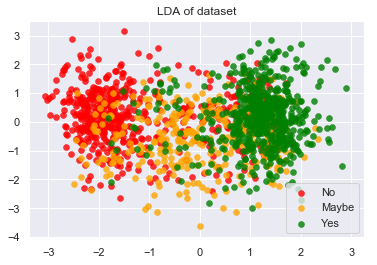

```python
from sklearn.discriminant_analysis import LinearDiscriminantAnalysis

lda = LinearDiscriminantAnalysis(n_components=2)
X_r2 = lda.fit(X, y).transform(X)

colors = ['red', 'orange', 'green']
target_names = ['No',"Maybe",'Yes']
lw = 0.5
for color, i, target_name in zip(colors, [0, 1, 2], target_names):
    plt.scatter(X_r2[y == i, 0], X_r2[y == i, 1], alpha=.8, color=color,
                label=target_name, lw=lw)
plt.legend(loc='best', shadow=False, scatterpoints=1)
plt.title('LDA of dataset')
plt.show()
```

### Decision trees

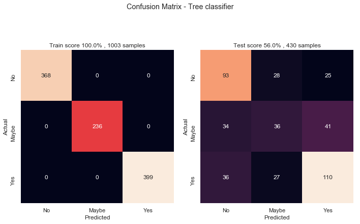

[output not shown]

```python
from sklearn import tree
tree_clf = tree.DecisionTreeClassifier(criterion="gini", random_state=20)
evaluate(tree_clf,"Tree classifier")
# import graphviz
# dot_data = tree.export_graphviz(tree_clf, out_file="tree.dot", feature_names= X.columns, filled=True, rounded=True, special_characters=True)
# from subprocess import call
# call(['dot.bat', '-T', 'png', 'tree.dot', '-o', 'tree.png'])
```

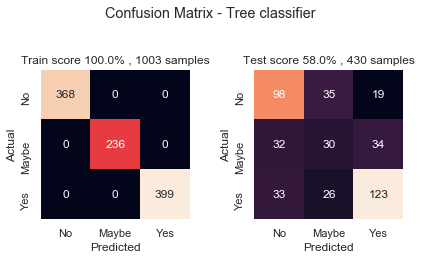

```python
tree_clf = tree.DecisionTreeClassifier(criterion="entropy", random_state=20)
evaluate(tree_clf,"Tree classifier")
```

### Linear Models

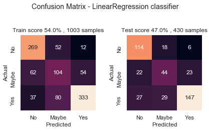

```python
from sklearn.linear_model import LinearRegression
lr_clf = LinearRegression()
evaluate(lr_clf,"LinearRegression classifier")
```

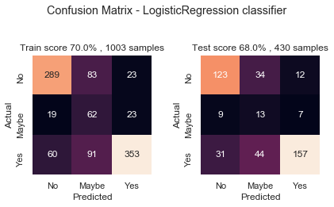

```python
from sklearn.linear_model import LogisticRegression
logreg_clf = LogisticRegression(multi_class="auto",solver="liblinear")
evaluate(logreg_clf ,"LogisticRegression classifier")
```

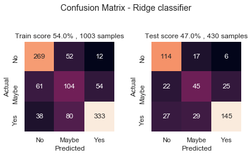

```python
from sklearn.linear_model import Ridge
ridge_clf = Ridge()
evaluate(ridge_clf ,"Ridge classifier")
```

All for linear models we are evaluation linear regression, logistic regression and a ridge classifier. All three models are generalizing decently well, since the absolute difference between their training and test scores are relatively low. The best linear classifier is using a logistic regression and gets scores around 70%.

### KNN Classifier

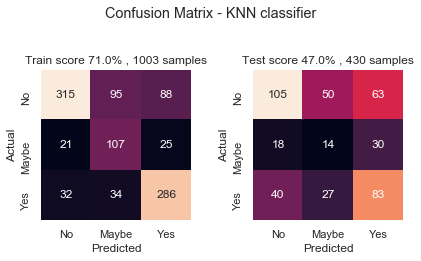

```python
from sklearn.neighbors import KNeighborsClassifier
knn_clf = KNeighborsClassifier(n_neighbors=3)
evaluate(knn_clf ,"KNN classifier")
```

### Propabilistic Classifiers

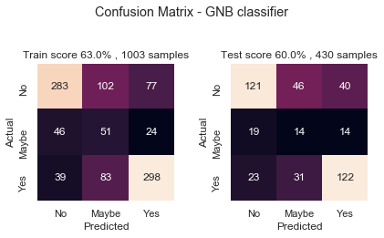

```python
from sklearn.naive_bayes import GaussianNB
gnb_clf = GaussianNB()
evaluate(gnb_clf ,"GNB classifier")
```

### Support Vector Machines

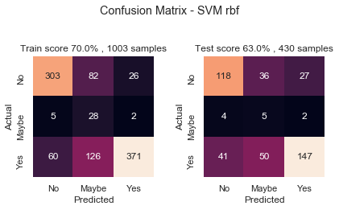

```
900
```

```python
from sklearn.svm import SVC
svm_rbf_clf = SVC(gamma='scale',kernel="rbf")
evaluate(svm_rbf_clf,"SVM rbf")
len(svm_rbf_clf.support_vectors_)
```

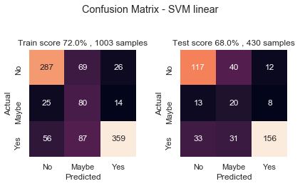

```
611
```

```python
from sklearn.svm import SVC
svm_lin_clf = SVC(gamma='scale',kernel="linear")
evaluate(svm_lin_clf,"SVM linear")
len(svm_lin_clf.support_vectors_)
```

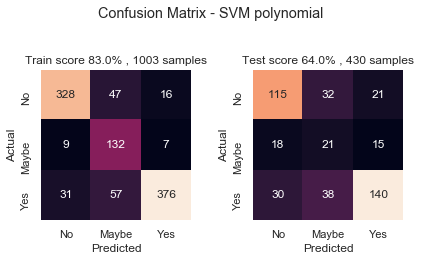

```
681
```

```python
from sklearn.svm import SVC
svm_poly_clf = SVC(gamma='scale',kernel="poly")
evaluate(svm_poly_clf,"SVM polynomial")
len(svm_poly_clf.support_vectors_)
```

## 1.3. Classification - Results and Discussion

Summarizing our observations we can say that:

- Tree models and KNN models are overfitting a lot
- The linear SVM and the logistic regression are the overall best performing models

## Task 2 (Unsupervised Learning) - Charactering people with mental health disorders

In this task you should **use unsupervised learning algorithms and try to characterize people with mental health disorders**:

- Use association rule mining to find **associations between features and mental health disorders**.
- Use **clustering algorithms to find groups describing similar people**, for example, is it possible to find groups of people with the same/similar mental health disorders.
- **Be creative and define your own unsupervised analysis!** What would it be interesting to find out ?

## 2.1. Preprocessing Data for Association Rule Mining

```python
rule_df = refactored_df.copy()
```

```python
# add additional columns
disorder_set = set()
for unique_cell in rule_df['Q49'].unique():
    disorders = unique_cell.split('|')
    for disorder in disorders:
        disorder_set.add(disorder)
for disorder in disorder_set:
    rule_df['Q49: {}'.format(disorder)] = False
```

```python
# split
for index, row in rule_df.iterrows():
    disorders = row['Q49'].split('|')
    for disorder in disorders:
        rule_df['Q49: {}'.format(disorder)][index] = True
```

```python
rule_df.head()
```

|  | Q1 | Q2 | Q3 | Q5 | Q6 | Q7 | Q8 | Q9 | Q10 | Q11 | Q12 | Q13 | Q14 | Q15 | Q16 | Q17 | Q18 | Q19 | Q21 | Q22 | Q23 | Q24 | Q25 | Q26 | Q27 | Q28 | Q29 | Q30 | Q31 | … |
| --- | --- | --- | --- | --- | --- | --- | --- | --- | --- | --- | --- | --- | --- | --- | --- | --- | --- | --- | --- | --- | --- | --- | --- | --- | --- | --- | --- | --- | --- | --- |
| 0 | 0 | 26-100 | 1 | Not eligible for coverage / N/A | No | No | No | I don't know | Very easy | No | No | Maybe | Yes | I don't know | No | Not asked | Not asked | Not asked | Not asked | Not asked | Not asked | Not asked | 1 | No, none did | N/A (not currently aware) | I don't know | None did | I don't know | Some of them | … |
| 1 | 0 | 6-25 | 1 | No | Yes | Yes | Yes | Yes | Somewhat easy | No | No | Maybe | Yes | Yes | No | Not asked | Not asked | Not asked | Not asked | Not asked | Not asked | Not asked | 1 | Yes, they all did | I was aware of some | None did | Some did | Yes, always | None of them | … |
| 2 | 0 | 6-25 | 1 | No | No | No | No | I don't know | Neither easy nor difficult | Maybe | No | Maybe | Maybe | I don't know | No | Not asked | Not asked | Not asked | Not asked | Not asked | Not asked | Not asked | 1 | No, none did | N/A (not currently aware) | None did | Some did | I don't know | I don't know | … |
| 3 | 1 | Not asked | Not asked | Not asked | Not asked | Not asked | Not asked | Not asked | Not asked | Not asked | Not asked | Not asked | Not asked | Not asked | Not asked | 1 | Yes, I know several | Sometimes, if it comes up | Sometimes, if it comes up | I'm not sure | Yes | 1-25% | 1 | Some did | N/A (not currently aware) | None did | None did | I don't know | Some of them | … |
| 4 | 0 | 6-25 | 0 | Yes | Yes | No | No | No | Neither easy nor difficult | Yes | Maybe | Maybe | No | No | No | Not asked | Not asked | Not asked | Not asked | Not asked | Not asked | Not asked | 1 | I don't know | N/A (not currently aware) | Some did | None did | I don't know | Some of them | … |

```python
rule_df = rule_df.drop('Q49', axis=1)
```

```python
rule_df.head()
```

|  | Q1 | Q2 | Q3 | Q5 | Q6 | Q7 | Q8 | Q9 | Q10 | Q11 | Q12 | Q13 | Q14 | Q15 | Q16 | Q17 | Q18 | Q19 | Q21 | Q22 | Q23 | Q24 | Q25 | Q26 | Q27 | Q28 | Q29 | Q30 | Q31 | … |
| --- | --- | --- | --- | --- | --- | --- | --- | --- | --- | --- | --- | --- | --- | --- | --- | --- | --- | --- | --- | --- | --- | --- | --- | --- | --- | --- | --- | --- | --- | --- |
| 0 | 0 | 26-100 | 1 | Not eligible for coverage / N/A | No | No | No | I don't know | Very easy | No | No | Maybe | Yes | I don't know | No | Not asked | Not asked | Not asked | Not asked | Not asked | Not asked | Not asked | 1 | No, none did | N/A (not currently aware) | I don't know | None did | I don't know | Some of them | … |
| 1 | 0 | 6-25 | 1 | No | Yes | Yes | Yes | Yes | Somewhat easy | No | No | Maybe | Yes | Yes | No | Not asked | Not asked | Not asked | Not asked | Not asked | Not asked | Not asked | 1 | Yes, they all did | I was aware of some | None did | Some did | Yes, always | None of them | … |
| 2 | 0 | 6-25 | 1 | No | No | No | No | I don't know | Neither easy nor difficult | Maybe | No | Maybe | Maybe | I don't know | No | Not asked | Not asked | Not asked | Not asked | Not asked | Not asked | Not asked | 1 | No, none did | N/A (not currently aware) | None did | Some did | I don't know | I don't know | … |
| 3 | 1 | Not asked | Not asked | Not asked | Not asked | Not asked | Not asked | Not asked | Not asked | Not asked | Not asked | Not asked | Not asked | Not asked | Not asked | 1 | Yes, I know several | Sometimes, if it comes up | Sometimes, if it comes up | I'm not sure | Yes | 1-25% | 1 | Some did | N/A (not currently aware) | None did | None did | I don't know | Some of them | … |
| 4 | 0 | 6-25 | 0 | Yes | Yes | No | No | No | Neither easy nor difficult | Yes | Maybe | Maybe | No | No | No | Not asked | Not asked | Not asked | Not asked | Not asked | Not asked | Not asked | 1 | I don't know | N/A (not currently aware) | Some did | None did | I don't know | Some of them | … |

Next preprocessing step specifilcally for Association rule mining is putting columns with large amounts of distinct orderable values into buckets to reduce the amount of columns we need overall later in the on hot encoding.

```python
rule_df.nunique()[rule_df.nunique() > 10] # These are our candidates, for bucketing.
```

```
Q56    49
Q58    53
Q59    48
Q60    53
Q61    49
dtype: int64
```

```python
rule_df['Q56'].unique() # => split into buckets 0-25, 25-...
```

```
array([39, 29, 38, 43, 42, 30, 37, 44, 28, 34, 35, 52, 32, 25, 31, 26, 33,
       27, 36, 40, 46, 41, 45, 19, 21, 24, 17, 23, 22, 51, 48, 55, 50, 49,
       20, 54, 47, 56, 57, 63, 61, 62, 53, 58, 66, 59, 65, 74, 70],
      dtype=int64)
```

```python
rule_df['Q56: 0-25'] = rule_df['Q56'].apply(lambda x: True if int(x) > 0 and int(x) <= 25 else False)
rule_df['Q56: 26-50'] = rule_df['Q56'].apply(lambda x: True if int(x) > 25 and int(x) <= 50 else False)
rule_df['Q56: 51-75'] = rule_df['Q56'].apply(lambda x: True if int(x) > 51 and int(x) <= 75 else False)
rule_df['Q56: 76-100'] = rule_df['Q56'].apply(lambda x: True if int(x) > 75 and int(x) <= 100 else False)
rule_df = rule_df.drop('Q56', axis=1)
```

```python
rule_df['Q58'].unique()
```

```
array(['United Kingdom', 'United States of America', 'Canada', 'Germany',
       'Netherlands', 'Czech Republic', 'Lithuania', 'Australia',
       'France', 'Venezuela', 'Poland', 'Belgium', 'Brazil', 'Denmark',
       'Sweden', 'Russia', 'Spain', 'India', 'Mexico', 'Switzerland',
       'Norway', 'Argentina', 'Ireland', 'Italy', 'Finland', 'Colombia',
       'Costa Rica', 'Vietnam', 'Bulgaria', 'New Zealand', 'South Africa',
       'Slovakia', 'Austria', 'Bangladesh', 'Algeria', 'Pakistan',
       'Afghanistan', 'Greece', 'Romania', 'Other', 'Brunei', 'Japan',
       'Iran', 'Hungary', 'Israel', 'Ecuador', 'Bosnia and Herzegovina',
       'China', 'Chile', 'Guatemala', 'Taiwan', 'Serbia', 'Estonia'],
      dtype=object)
```

```python
rule_df['Q59'].unique()
```

```
array(['Not USA', 'Illinois', 'Tennessee', 'Virginia', 'California',
       'Kentucky', 'Oregon', 'Pennsylvania', 'New Jersey', 'Georgia',
       'Washington', 'New York', 'Indiana', 'Minnesota', 'West Virginia',
       'Florida', 'Massachusetts', 'North Dakota', 'Texas', 'Maryland',
       'Wisconsin', 'Michigan', 'Vermont', 'North Carolina', 'Kansas',
       'District of Columbia', 'Nevada', 'Utah', 'Connecticut',
       'Colorado', 'Ohio', 'Iowa', 'South Dakota', 'Nebraska', 'Maine',
       'Missouri', 'Arizona', 'Oklahoma', 'Idaho', 'Rhode Island',
       'Alabama', 'Louisiana', 'South Carolina', 'New Hampshire',
       'New Mexico', 'Montana', 'Alaska', 'Delaware'], dtype=object)
```

```python
rule_df['Q60'].unique()
```

```
array(['United Kingdom', 'United States of America', 'Canada', 'Germany',
       'Netherlands', 'Czech Republic', 'Lithuania', 'Australia',
       'France', 'Venezuela', 'Poland', 'Belgium', 'Brazil', 'Denmark',
       'Sweden', 'Russia', 'Spain', 'India', 'United Arab Emirates',
       'Mexico', 'Switzerland', 'Norway', 'Argentina', 'Ireland', 'Italy',
       'Finland', 'Turkey', 'Colombia', 'Costa Rica', 'Vietnam',
       'Bulgaria', 'New Zealand', 'South Africa', 'Slovakia', 'Austria',
       'Bangladesh', 'Pakistan', 'Afghanistan', 'Greece', 'Other',
       'Romania', 'Brunei', 'Iran', 'Hungary', 'Israel', 'Japan',
       'Ecuador', 'Bosnia and Herzegovina', 'China', 'Chile', 'Guatemala',
       'Serbia', 'Estonia'], dtype=object)
```

```python
rule_df['Q61'].unique()
```

```
array(['Not USA', 'Illinois', 'Tennessee', 'Virginia', 'California',
       'Kentucky', 'Oregon', 'Pennsylvania', 'New Jersey', 'Georgia',
       'Washington', 'New York', 'Indiana', 'Minnesota', 'Ohio',
       'Florida', 'Massachusetts', 'North Dakota', 'Texas',
       'District of Columbia', 'Michigan', 'Vermont', 'North Carolina',
       'Missouri', 'Kansas', 'Nevada', 'Utah', 'Connecticut', 'Maryland',
       'Colorado', 'Iowa', 'South Dakota', 'Hawaii', 'Nebraska', 'Maine',
       'Arizona', 'Oklahoma', 'Wisconsin', 'Rhode Island', 'Alabama',
       'West Virginia', 'Louisiana', 'South Carolina', 'New Hampshire',
       'New Mexico', 'Montana', 'Idaho', 'Alaska', 'Delaware'],
      dtype=object)
```

At this point to reduce the number of columns needed for one hot encoding, we make the assumption that the country column is sufficient enough, hence not differentiating between any states in the USA

```python
rule_df = rule_df.drop('Q59', axis=1)
rule_df = rule_df.drop('Q61', axis=1)
```

Q54 - "If you have a mental health issue, do you feel that it interferes with your work when being treated effectively?" Q55 - "If you have a mental health issue, do you feel that it interferes with your work when NOT being treated effectively?" are both not helping for the ruleso with the selected objective. so we remove them.

```python
rule_df = rule_df.drop('Q55', axis=1) # for performance
rule_df = rule_df.drop('Q54', axis=1) # for performance
```

```python
def transform_into_matrix(df):
    column_names = df.columns
    df.columns = column_names
    for name in column_names:
        df[name] = df[name].apply(lambda x: '{}: '.format(name) + str(x) if pd.notnull(x) else np.nan)
    return df.as_matrix()
```

```python
def clean_lists_from_nan(input_lists):
    cleaned_lists = []
    for l in input_lists:
        l = [x for x in l if str(x) != 'nan']
        cleaned_lists.append(l)
    return cleaned_lists
```

```python
input_lists = transform_into_matrix(rule_df).tolist()
cleaned_lists = clean_lists_from_nan(input_lists)
```

```python
len(rule_df.columns)
```

```
97
```

```python
#cleaned_lists
```

Transformation: One hot encoding across all columns, across all values

```python
from mlxtend.preprocessing import OnehotTransactions
#Compute binary database
oht = OnehotTransactions()
oht_ary = oht.fit(cleaned_lists).transform(cleaned_lists)
binary_database = pd.DataFrame(oht_ary, columns=oht.columns_)
# shorten col names
#old_names = [x for x in binary_database.columns]
#short_names = [x[:25] for x in old_names]
#binary_database.columns = short_names
```

```python
# deleted redundant information columns
binary_database = binary_database.drop([col for col in binary_database.columns if 'False' in col],axis=1)
```

```python
binary_database.head(20)
```

|  | Q10: I don't know | Q10: Neither easy nor difficult | Q10: Not asked | Q10: Somewhat difficult | Q10: Somewhat easy | Q10: Very difficult | Q10: Very easy | Q11: Maybe | Q11: No | Q11: Not asked | Q11: Yes | Q12: Maybe | Q12: No | Q12: Not asked | Q12: Yes | Q13: Maybe | Q13: No | Q13: Not asked | Q13: Yes | Q14: Maybe | Q14: No | Q14: Not asked | Q14: Yes | Q15: I don't know | Q15: No | Q15: Not asked | Q15: Yes | Q16: No | Q16: Not asked | … |
| --- | --- | --- | --- | --- | --- | --- | --- | --- | --- | --- | --- | --- | --- | --- | --- | --- | --- | --- | --- | --- | --- | --- | --- | --- | --- | --- | --- | --- | --- | --- |
| 0 | False | False | False | False | False | False | True | False | True | False | False | False | True | False | False | True | False | False | False | False | False | False | True | True | False | False | False | True | False | … |
| 1 | False | False | False | False | True | False | False | False | True | False | False | False | True | False | False | True | False | False | False | False | False | False | True | False | False | False | True | True | False | … |
| 2 | False | True | False | False | False | False | False | True | False | False | False | False | True | False | False | True | False | False | False | True | False | False | False | True | False | False | False | True | False | … |
| 3 | False | False | True | False | False | False | False | False | False | True | False | False | False | True | False | False | False | True | False | False | False | True | False | False | False | True | False | False | True | … |
| 4 | False | True | False | False | False | False | False | False | False | False | True | True | False | False | False | True | False | False | False | False | True | False | False | False | True | False | False | True | False | … |
| 5 | False | False | False | False | True | False | False | False | False | False | True | False | False | False | True | True | False | False | False | False | False | False | True | False | True | False | False | False | False | … |
| 6 | False | False | False | False | True | False | False | False | True | False | False | False | True | False | False | True | False | False | False | False | False | False | True | False | False | False | True | True | False | … |
| 7 | False | False | False | False | False | False | True | False | True | False | False | False | True | False | False | True | False | False | False | False | False | False | True | True | False | False | False | True | False | … |
| 8 | False | False | False | False | False | True | False | False | False | False | True | False | False | False | True | False | False | False | True | True | False | False | False | False | True | False | False | True | False | … |
| 9 | False | False | True | False | False | False | False | False | False | True | False | False | False | True | False | False | False | True | False | False | False | True | False | False | False | True | False | False | True | … |
| 10 | False | False | False | False | False | False | True | False | True | False | False | False | True | False | False | True | False | False | False | False | False | False | True | False | False | False | True | True | False | … |
| 11 | False | False | False | True | False | False | False | False | False | False | True | False | True | False | False | False | True | False | False | False | True | False | False | False | True | False | False | True | False | … |
| 12 | False | False | False | False | False | False | True | False | True | False | False | False | True | False | False | False | False | False | True | False | False | False | True | False | False | False | True | True | False | … |
| 13 | False | False | False | False | True | False | False | False | True | False | False | False | True | False | False | False | True | False | False | True | False | False | False | False | False | False | True | True | False | … |
| 14 | False | False | False | False | False | False | True | False | True | False | False | False | True | False | False | False | False | False | True | False | False | False | True | False | True | False | False | True | False | … |
| 15 | False | True | False | False | False | False | False | True | False | False | False | True | False | False | False | True | False | False | False | True | False | False | False | True | False | False | False | True | False | … |
| 16 | False | False | False | False | False | True | False | True | False | False | False | False | True | False | False | True | False | False | False | True | False | False | False | False | True | False | False | True | False | … |
| 17 | True | False | False | False | False | False | False | True | False | False | False | False | True | False | False | False | False | False | True | True | False | False | False | False | True | False | False | True | False | … |
| 18 | False | False | True | False | False | False | False | False | False | True | False | False | False | True | False | False | False | True | False | False | False | True | False | False | False | True | False | False | True | … |
| 19 | True | False | False | False | False | False | False | False | False | False | True | False | True | False | False | False | True | False | False | False | True | False | False | False | False | False | True | True | False | … |

```python
len(binary_database.columns)
```

```
355
```

## 2.2. Finding Associations

```python
from mlxtend.frequent_patterns import apriori
```

```python
min_sup = 0.1
```

```python
frequent_itemsets = apriori(binary_database, min_support=min_sup, max_len=5, use_colnames=True)
frequent_itemsets.head()
%time
```

```
Wall time: 1 ms
```

```python
frequent_itemsets.head()
```

|  | support | itemsets |
| --- | --- | --- |
| 0 | 0.104676 | (Q10: I don't know) |
| 1 | 0.124215 | (Q10: Neither easy nor difficult) |
| 2 | 0.200279 | (Q10: Not asked) |
| 3 | 0.138870 | (Q10: Somewhat difficult) |
| 4 | 0.196092 | (Q10: Somewhat easy) |

```python
from mlxtend.frequent_patterns import association_rules
```

```python
pd.set_option('display.max_rows', 500)
pd.set_option('display.max_columns', 500)
pd.set_option('display.width', 1000)
```

```python
rules = association_rules(frequent_itemsets, metric="confidence", min_threshold=0.8)
rules[rules['consequents'] == {"Q48: Yes"}]
```

|  | antecedents | consequents | antecedent support | consequent support | support | confidence | lift | leverage | conviction |
| --- | --- | --- | --- | --- | --- | --- | --- | --- | --- |
| 46267 | (Q49: Anxiety Disorder (Generalized, Social, P... | (Q48: Yes) | 0.272854 | 0.401256 | 0.219819 | 0.805627 | 2.007762 | 0.110334 | 3.080380 |
| 46269 | (Q49: Mood Disorder (Depression, Bipolar Disor... | (Q48: Yes) | 0.329379 | 0.401256 | 0.269365 | 0.817797 | 2.038091 | 0.137200 | 3.286129 |
| 153612 | (Q49: Anxiety Disorder (Generalized, Social, P... | (Q48: Yes) | 0.161200 | 0.401256 | 0.132589 | 0.822511 | 2.049840 | 0.067906 | 3.373411 |
| 153614 | (Q49: Mood Disorder (Depression, Bipolar Disor... | (Q48: Yes) | 0.187718 | 0.401256 | 0.154920 | 0.825279 | 2.056738 | 0.079597 | 3.426853 |
| 319132 | (Q16: No, Q49: Anxiety Disorder (Generalized, ... | (Q48: Yes) | 0.190509 | 0.401256 | 0.153524 | 0.805861 | 2.008345 | 0.077081 | 3.084096 |
| 319134 | (Q16: No, Q49: Mood Disorder (Depression, Bipo... | (Q48: Yes) | 0.232380 | 0.401256 | 0.189812 | 0.816817 | 2.035650 | 0.096568 | 3.268553 |
| 387617 | (Q49: Anxiety Disorder (Generalized, Social, P... | (Q48: Yes) | 0.216329 | 0.401256 | 0.173761 | 0.803226 | 2.001778 | 0.086958 | 3.042797 |
| 387619 | (Q17: Not asked, Q49: Mood Disorder (Depressio... | (Q48: Yes) | 0.260991 | 0.401256 | 0.212840 | 0.815508 | 2.032388 | 0.108116 | 3.245365 |
| 441941 | (Q49: Anxiety Disorder (Generalized, Social, P... | (Q48: Yes) | 0.216329 | 0.401256 | 0.173761 | 0.803226 | 2.001778 | 0.086958 | 3.042797 |
| 441943 | (Q18: Not asked, Q49: Mood Disorder (Depressio... | (Q48: Yes) | 0.260991 | 0.401256 | 0.212840 | 0.815508 | 2.032388 | 0.108116 | 3.245365 |
| 487814 | (Q49: Anxiety Disorder (Generalized, Social, P... | (Q48: Yes) | 0.216329 | 0.401256 | 0.173761 | 0.803226 | 2.001778 | 0.086958 | 3.042797 |
| 487816 | (Q49: Mood Disorder (Depression, Bipolar Disor... | (Q48: Yes) | 0.260991 | 0.401256 | 0.212840 | 0.815508 | 2.032388 | 0.108116 | 3.245365 |
| 525900 | (Q49: Anxiety Disorder (Generalized, Social, P... | (Q48: Yes) | 0.216329 | 0.401256 | 0.173761 | 0.803226 | 2.001778 | 0.086958 | 3.042797 |
| 525902 | (Q49: Mood Disorder (Depression, Bipolar Disor... | (Q48: Yes) | 0.260991 | 0.401256 | 0.212840 | 0.815508 | 2.032388 | 0.108116 | 3.245365 |
| 560180 | (Q21: Not asked, Q49: Anxiety Disorder (Genera... | (Q48: Yes) | 0.216329 | 0.401256 | 0.173761 | 0.803226 | 2.001778 | 0.086958 | 3.042797 |
| 560182 | (Q21: Not asked, Q49: Mood Disorder (Depressio... | (Q48: Yes) | 0.260991 | 0.401256 | 0.212840 | 0.815508 | 2.032388 | 0.108116 | 3.245365 |
| 584642 | (Q49: Anxiety Disorder (Generalized, Social, P... | (Q48: Yes) | 0.216329 | 0.401256 | 0.173761 | 0.803226 | 2.001778 | 0.086958 | 3.042797 |
| 584644 | (Q22: Not asked, Q49: Mood Disorder (Depressio... | (Q48: Yes) | 0.260991 | 0.401256 | 0.212840 | 0.815508 | 2.032388 | 0.108116 | 3.245365 |
| 603236 | (Q49: Anxiety Disorder (Generalized, Social, P... | (Q48: Yes) | 0.216329 | 0.401256 | 0.173761 | 0.803226 | 2.001778 | 0.086958 | 3.042797 |
| 603238 | (Q49: Mood Disorder (Depression, Bipolar Disor... | (Q48: Yes) | 0.260991 | 0.401256 | 0.212840 | 0.815508 | 2.032388 | 0.108116 | 3.245365 |
| 617434 | (Q24: Not asked, Q47: Yes, Q49: Anxiety Disord... | (Q48: Yes) | 0.216329 | 0.401256 | 0.173761 | 0.803226 | 2.001778 | 0.086958 | 3.042797 |
| 617436 | (Q24: Not asked, Q49: Mood Disorder (Depressio... | (Q48: Yes) | 0.260991 | 0.401256 | 0.212840 | 0.815508 | 2.032388 | 0.108116 | 3.245365 |
| 634889 | (Q25: 1, Q49: Anxiety Disorder (Generalized, S... | (Q48: Yes) | 0.247034 | 0.401256 | 0.198883 | 0.805085 | 2.006411 | 0.099759 | 3.071816 |
| 634893 | (Q25: 1, Q49: Mood Disorder (Depression, Bipol... | (Q48: Yes) | 0.302163 | 0.401256 | 0.247034 | 0.817552 | 2.037482 | 0.125789 | 3.281723 |
| 644158 | (Q28: None did, Q49: Anxiety Disorder (General... | (Q48: Yes) | 0.180042 | 0.401256 | 0.147941 | 0.821705 | 2.047833 | 0.075698 | 3.358172 |
| 644160 | (Q28: None did, Q49: Mood Disorder (Depression... | (Q48: Yes) | 0.219121 | 0.401256 | 0.180042 | 0.821656 | 2.047710 | 0.092118 | 3.357243 |
| 646794 | (Q49: Anxiety Disorder (Generalized, Social, P... | (Q48: Yes) | 0.154920 | 0.401256 | 0.129798 | 0.837838 | 2.088038 | 0.067635 | 3.692254 |
| 646796 | (Q29: None did, Q49: Mood Disorder (Depression... | (Q48: Yes) | 0.195394 | 0.401256 | 0.161200 | 0.825000 | 2.056043 | 0.082797 | 3.421394 |
| 651255 | (Q49: Anxiety Disorder (Generalized, Social, P... | (Q48: Yes) | 0.136776 | 0.401256 | 0.110956 | 0.811224 | 2.021713 | 0.056074 | 3.171724 |
| 651257 | (Q31: Some of them, Q49: Mood Disorder (Depres... | (Q48: Yes) | 0.159107 | 0.401256 | 0.127704 | 0.802632 | 2.000297 | 0.063862 | 3.033636 |

[output cut: 471 more lines]

630 rows × 9 columns

```python
top_5_rules = rules[rules['consequents'] == {"Q48: Yes"}].sort_values(by='support', ascending=False).head(5)
top_5_rules
```

|  | antecedents | consequents | antecedent support | consequent support | support | confidence | lift | leverage | conviction |
| --- | --- | --- | --- | --- | --- | --- | --- | --- | --- |
| 46269 | (Q49: Mood Disorder (Depression, Bipolar Disor... | (Q48: Yes) | 0.329379 | 0.401256 | 0.269365 | 0.817797 | 2.038091 | 0.137200 | 3.286129 |
| 659612 | (Q53: 1, Q49: Mood Disorder (Depression, Bipol... | (Q48: Yes) | 0.309142 | 0.401256 | 0.253315 | 0.819413 | 2.042120 | 0.129270 | 3.315544 |
| 634893 | (Q25: 1, Q49: Mood Disorder (Depression, Bipol... | (Q48: Yes) | 0.302163 | 0.401256 | 0.247034 | 0.817552 | 2.037482 | 0.125789 | 3.281723 |
| 5471489 | (Q25: 1, Q53: 1, Q49: Mood Disorder (Depressio... | (Q48: Yes) | 0.284717 | 0.401256 | 0.232380 | 0.816176 | 2.034054 | 0.118135 | 3.257167 |
| 659616 | (Q56: 26-50: True, Q49: Mood Disorder (Depress... | (Q48: Yes) | 0.279135 | 0.401256 | 0.226099 | 0.810000 | 2.018661 | 0.114095 | 3.151284 |

## 2.3 Association Rules - Results and Discussion

```python
rule_sets = [set(x) for x in top_5_rules['antecedents'].tolist()]
rule_sets
```

```
[{'Q47: Yes', 'Q49: Mood Disorder (Depression, Bipolar Disorder, etc): True'},
 {'Q47: Yes',
  'Q49: Mood Disorder (Depression, Bipolar Disorder, etc): True',
  'Q53: 1'},
 {'Q25: 1',
  'Q47: Yes',
  'Q49: Mood Disorder (Depression, Bipolar Disorder, etc): True'},
 {'Q25: 1',
  'Q47: Yes',
  'Q49: Mood Disorder (Depression, Bipolar Disorder, etc): True',
  'Q53: 1'},
 {'Q47: Yes',
  'Q49: Mood Disorder (Depression, Bipolar Disorder, etc): True',
  'Q56: 26-50: True'}]
```

We took here the top five rules, we mined. As consequent we always analyze if the instance suffers under a mental disorder or not. Across the top 5 rules, we see that the in every of these instances the person had a mental disorder in the past (Q47). That gives us a clear insight on the influence. While we are only filitering for any mental disorder, the mood disorder is present in all 5 antecedents. Also people between 25 and 50, who have been diagnosed with a mental issue in the past are likely to suffer under one again, especially under a mood disorder. Also the antecedent of only 1 previous employer occurres often (Q25). This might actually come from the fact that most asked people had only 1 previous employer.

## 2.4. Preprocess Data for Clustering

```python
import re
clustering_df = normalised_df.copy()
clustering_df['Q49'].value_counts()[:5]
```

```
Not identified                                                                                                                                    541
Anxiety Disorder (Generalized, Social, Phobia, etc)|Mood Disorder (Depression, Bipolar Disorder, etc)                                             166
Mood Disorder (Depression, Bipolar Disorder, etc)                                                                                                 158
Anxiety Disorder (Generalized, Social, Phobia, etc)                                                                                                82
Anxiety Disorder (Generalized, Social, Phobia, etc)|Mood Disorder (Depression, Bipolar Disorder, etc)|Attention Deficit Hyperactivity Disorder     37
Name: Q49, dtype: int64
```

#### Divide rows with multiple mental health conditions into multiple rows with one mental health condition

```python
clustering_df['Q49'] = clustering_df['Q49'].map(lambda x: re.sub("\([^\(]*\)", "", x.lower()))
clustering_df['Q49'].value_counts()[:5]
```

```
not identified                                                               541
anxiety disorder |mood disorder                                              166
mood disorder                                                                158
anxiety disorder                                                              82
anxiety disorder |mood disorder |attention deficit hyperactivity disorder     37
Name: Q49, dtype: int64
```

```python
clustering_df['Q49'] = clustering_df['Q49'].map(lambda x: [y.strip() for y in x.replace('/', '|').split('|')])
clustering_df['Q49'].value_counts()[:5]
```

```
[not identified]                                                               541
[anxiety disorder, mood disorder]                                              166
[mood disorder]                                                                158
[anxiety disorder]                                                              82
[anxiety disorder, mood disorder, attention deficit hyperactivity disorder]     37
Name: Q49, dtype: int64
```

```python
dis = clustering_df['Q49']
set(sum(dis, []))
```

```
{'add',
 'addictive disorder',
 'anxiety',
 'anxiety disorder',
 'asperger syndrome',
 "asperger's",
 'asperges',
 'attention deficit hyperactivity disorder',
 'autism',
 'autism spectrum disorder',
 'burn out',
 'burnout',
 'combination of physical impairment  with a possibly mental one',
 'depersonalisation',
 'depersonalization disorder',
 'depression',
 'dissociative disorder',
 'eating disorder',
 'gender dysphoria',
 'gender identity disorder',
 "i haven't been formally diagnosed, so i felt uncomfortable answering, but social anxiety and depression.",
 'intimate disorder',
 'mood disorder',
 'not identified',
 'obsessive-compulsive disorder',
 'pdd-nos',
 'personality disorder',
 'pervasive developmental disorder',
 'post-partum',
 'post-traumatic stress disorder',
 'psychotic disorder',
 'ptsd',
 'schizotypal personality disorder',
 'seasonal affective disorder',
 'sexual addiction',
 'sleeping disorder',
 'stress response syndromes',
 'substance use disorder',
 'suicidal ideation',
 'tinnitus',
 'transgender',
 'traumatic brain injury'}
```

#### Cleaning data from multiple versions of the same string

```python
disorder_mapping = {'add': 'addictive disorder',
 'anxiety': 'anxiety disorder',
 "asperger's": 'asperger syndrome',
 'asperges': 'asperger syndrome',
 'burn out': 'burnout',
 'combination of physical impairment  with a possibly mental one': 'not identified',
 'depersonalisation': 'depersonalization disorder',
 'gender identity disorder': 'gender dysphoria',
 "i haven't been formally diagnosed, so i felt uncomfortable answering, but social anxiety and depression.": 'not identified',
 'pdd-nos': 'pervasive developmental disorder',
 'ptsd': 'post-traumatic stress disorder'}
```

```python
one_disorder_df = []
for _, row in clustering_df.iterrows():
    disorders = row['Q49']
    for disorder in disorders:
        tmp = row.copy()
        if disorder in disorder_mapping:
            tmp['Q49'] = disorder_mapping[disorder]
        else:
            tmp['Q49'] = disorder
        one_disorder_df.append(tmp)
one_disorder_df = pd.DataFrame(one_disorder_df)
len(one_disorder_df) == len(sum(dis, []))
```

```
True
```

#### Glance at the counts of mental health conditions

```python
one_disorder_df['Q49'].value_counts()
```

```
mood disorder                               634
not identified                              543
anxiety disorder                            539
attention deficit hyperactivity disorder    181
post-traumatic stress disorder               96
stress response syndromes                    78
personality disorder                         77
obsessive-compulsive disorder                75
addictive disorder                           60
substance use disorder                       55
eating disorder                              38
dissociative disorder                        17
psychotic disorder                           14
autism                                        5
asperger syndrome                             3
gender dysphoria                              2
autism spectrum disorder                      2
burnout                                       2
depersonalization disorder                    2
pervasive developmental disorder              2
depression                                    1
intimate disorder                             1
suicidal ideation                             1
sexual addiction                              1
post-partum                                   1
tinnitus                                      1
seasonal affective disorder                   1
sleeping disorder                             1
schizotypal personality disorder              1
traumatic brain injury                        1
transgender                                   1
Name: Q49, dtype: int64
```

## 2.5. Finding Groups

```python
from sklearn.cluster import KMeans, AgglomerativeClustering
from matplotlib.ticker import FuncFormatter
```

```python
def cluster_data(data, name_index):
    data = data.values
    x_data = np.delete(data, name_index, axis = 1)
    y_data = data[:, name_index]
    return (x_data, y_data)
```

```python
def frequencies(data):
    unique, counts = np.unique(data, return_counts=True)
    return dict(zip(unique, counts))
```

```python
def empty_dict(array):
    d = {}
    for i in set(array):
        d[i] = 0
    return d
```

```python
matplotlib.rcParams['figure.figsize'] = (10.0, 7.0)
def analyze_clusters(cluster, data):
    x_data, y_data = data
    freq = frequencies(y_data)
    cluster = cluster.fit(x_data)
    predicted = cluster.labels_
    correct = y_data
    size = max(predicted) + 1
    labels = []
    for i in range(size):
        labels.append(empty_dict(y_data))
    for i in range(len(predicted)):
        c = labels[predicted[i]]
        c[correct[i]] = c.get(correct[i], 0) + 1
    for i in labels:
        #for key in i:
         #   i[key] = (i[key] / freq[key]) * 100.0
        print('total: ' + str(sum(i.values())))
        fig, ax = plt.subplots()
        ax.yaxis.set_major_formatter(FuncFormatter(lambda val, pos: str(val) + '%'))
        plt.xticks(rotation='vertical')
        rects = plt.bar(i.keys(), [i[key] / freq[key] * 100.0 for key in i.keys()])
        for (rect, val) in zip(rects, i.values()):
            height = rect.get_height()
            plt.text(0.1 + rect.get_x()+rect.get_width()/2.0, height + 1, '%d'%int(val),
                    ha='center', va='bottom', rotation='vertical')
        plt.show()
```

#### The most obvious type of clustering will be cluster with people with and without disorders. So we run algorithms to output two clusters.

```
total: 2245
```

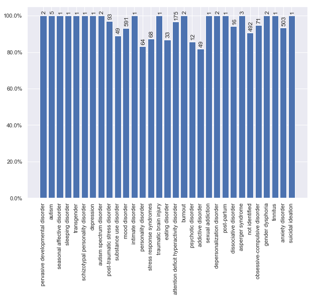

```
total: 191
```

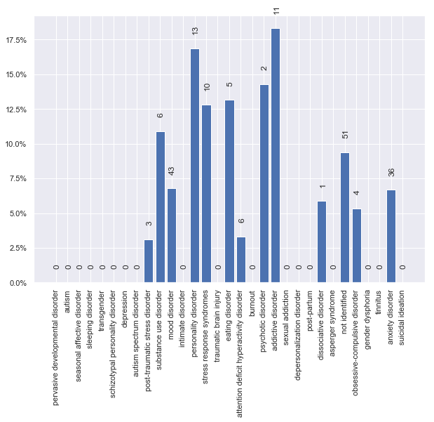

```python
analyze_clusters(AgglomerativeClustering(linkage="average", n_clusters=2), cluster_data(one_disorder_df, 44))
```

```
total: 688
```

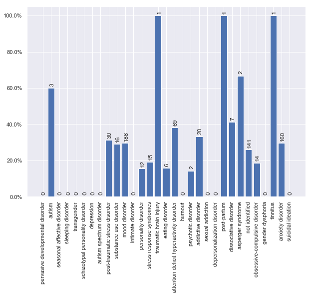

```
total: 1748
```

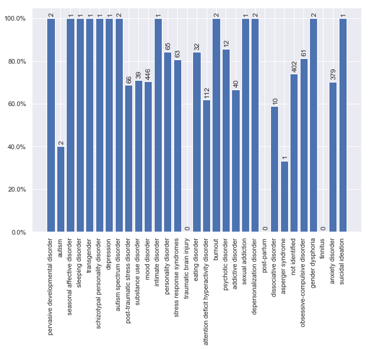

```python
analyze_clusters(KMeans(n_clusters=2, random_state=0), cluster_data(one_disorder_df, 44))
```

In both cases returned clusters do not show any specific division of disorders types. Clusters were divided into one bigger and one smaller cluster in terms of quantity of examples. Also, in the data there is a loot of disorders with rather small number of examples. We will try to delete this examples, and left only ones with bigger example count.

```python
counts = one_disorder_df['Q49'].value_counts()
to_delete = []
for key in counts.keys():
    if counts[key] < 50:
        to_delete.append(key)
```

```python
above_50_df = one_disorder_df[~one_disorder_df['Q49'].isin(to_delete)]
```

```python
above_50_df['Q49'].value_counts()
```

```
mood disorder                               634
not identified                              543
anxiety disorder                            539
attention deficit hyperactivity disorder    181
post-traumatic stress disorder               96
stress response syndromes                    78
personality disorder                         77
obsessive-compulsive disorder                75
addictive disorder                           60
substance use disorder                       55
Name: Q49, dtype: int64
```

#### This time we were left with 10 disorders types, so we will try to make clustering with 10 output clusters.

```
total: 1746
```

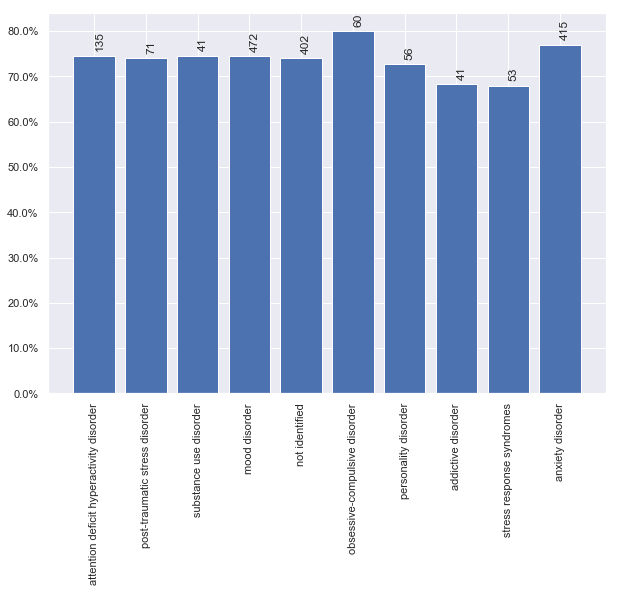

```
total: 130
```

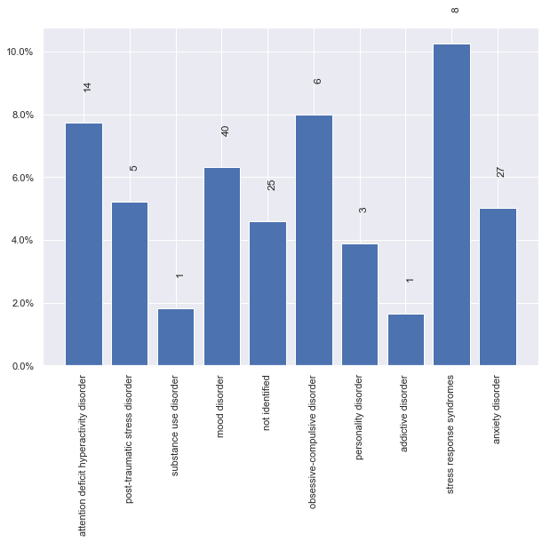

```
total: 13
```

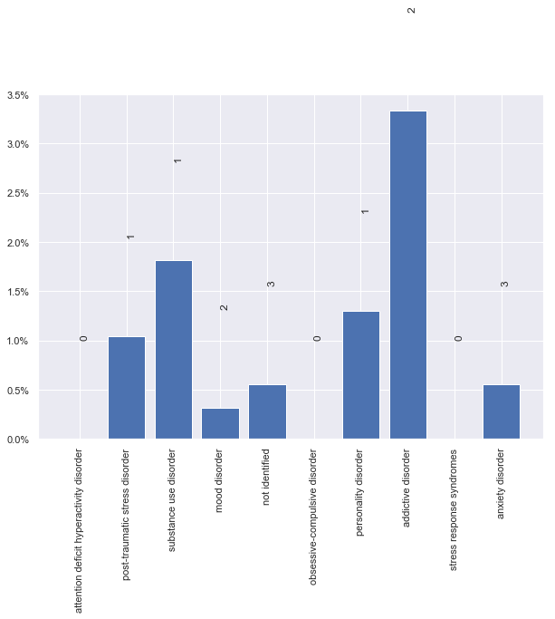

```
total: 74
```

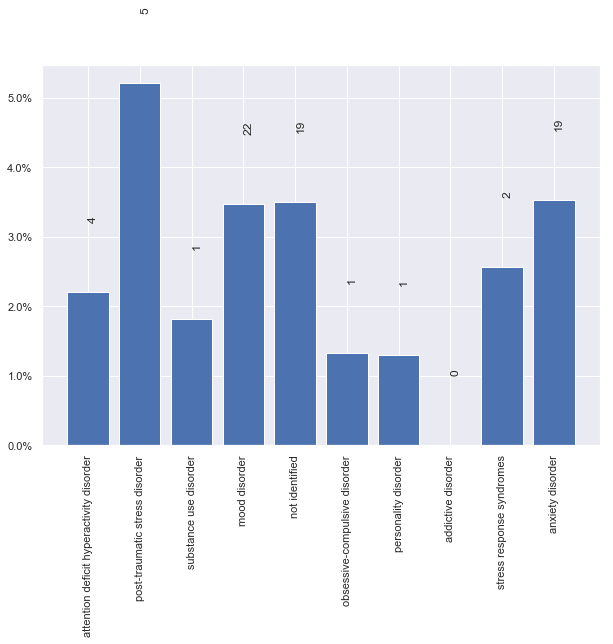

```
total: 203
```

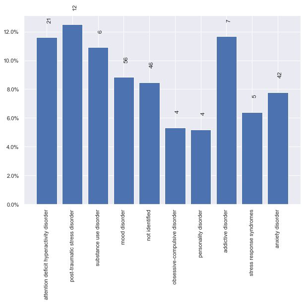

```
total: 2
```

[figure not shown]

```
total: 28
```

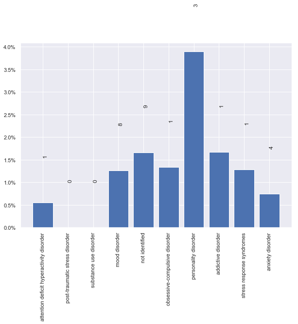

```
total: 1
```

[figure not shown]

```
total: 139
```

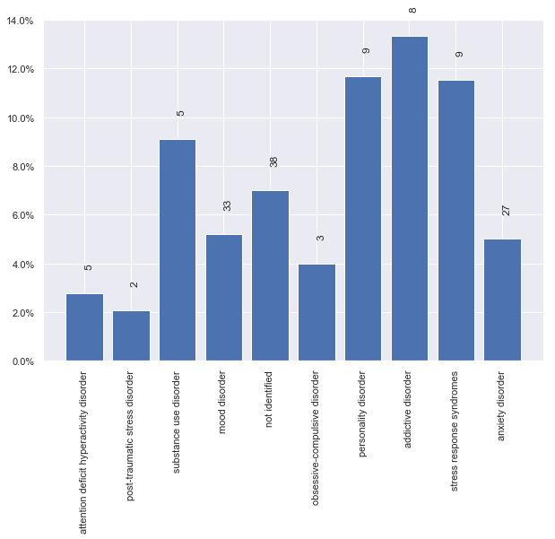

```
total: 2
```

[figure not shown]

```python
analyze_clusters(AgglomerativeClustering(linkage="average", n_clusters=10), cluster_data(above_50_df, 44))
```